# Impact des comportements alimentaires sur les profils lipidiques anormaux chez les personnes vivant avec le VIH (PVVIH) sous traitement antirétroviral, une analyse par modèles de médiation multiple

Memoire de Master 2 Sante Publique, MQERS

Lancinet KEITA

2026-02-26

# Introduction

Ce document présente le pipeline d’analyse structuré en cinq parties : (1) gestion des données, (2) qualité et valeurs manquantes, (3) construction des outcomes lipidiques, (4) analyse descriptive, (5) modélisation statistique — pour évaluer l’impact des comportements alimentaires sur les profils lipidiques.

# 1. Gestion des données (data management)

## 1.1 Installation et chargement des packages

## 1.2 Importation des bases sources

```r
labo  <- read_excel(here("data/MetaVIH_Donnees_Clinique_Laboratoire.xlsx")) |> clean_names()
quest <- read_excel(here("data/MetaVIH_Questionnaire.xlsx")) |> clean_names()

# glimpse(labo)
# glimpse(quest)
# glimpse(ta)
```

## 1.3 Construction des scores comportementaux et cliniques

### 1.3.1 Score REAPS

```r
#Création du score REAPS
reaps_items <- c("sautez_vous_souvent_le_petit_d_jeuner",
                 "prenez_vous_4_repas_place_ou_emporter",
                 "consommez_vous_moins_en_fibres_par_jour",
                 "consommez_vous_moins_de_fruits_par_jour",
                 "consommez_vous_moins_de_l_gumes_par_jour",
                 "consommez_vous_moins_ou_fromage_par_jour",
                 "consommez_vous_plus_ou_poisson_par_jour",
                 "utilisez_vous_des_vi_s_maigres_hot_dogs",
                 "consommez_vous_des_a_s_ou_le_manioc_frit",
                 "consommez_vous_des_c_orn_souffl_l_air",
                 "ajoutez_vous_du_beur_aux_l_gumes_table",
                 "consommez_vous_des_s_de_2_fois_par_jour",
                 "buvez_vous_16_onces_e_de_soda_12_onces",
                 "vous_m_me_ou_un_memb_anger_au_restaurant",
                 "vous_sentez_vous_g_n_courses_ou_cuisiner",
                 "dans_quelle_mesure_s_en_meilleure_sant")

quest <- quest |>
  mutate(
    REAPS = rowSums(across(all_of(reaps_items), as.numeric), na.rm = TRUE),
    REAPS_cat = case_when(
      REAPS <= 5 ~ "Alimentation saine",
      REAPS <= 10 ~ "Alimentation modérément saine",
      REAPS > 10 ~ "Alimentation à risque"
    )
  )
```

### 1.3.2 Niveau d’activité physique (IPAQ)

```r
# Coefficients MET IPAQ
MET_intense  <- 8.0
MET_moderee  <- 4.0
MET_marche   <- 3.3

# Création des variables minutes/jour
quest <- quest |>
  mutate(
    # Activité intense
    duree_intense = ifelse(!is.na(heures_s_par_jour), heures_s_par_jour*60, 0) +
                    ifelse(!is.na(minutes_par_jour), minutes_par_jour, 0),
    MET_intense = au_cours_des_7_derniers_jours * duree_intense * MET_intense,

    # Activité modérée
    duree_moderee = ifelse(!is.na(heures_s_par_jour_001), heures_s_par_jour_001*60, 0) +
                    ifelse(!is.na(minutes_par_jour_001), minutes_par_jour_001, 0),
    MET_moderee = au_cours_des_7_derniers_jours_001 * duree_moderee * MET_moderee,

    # Marche
    duree_marche = ifelse(!is.na(heures_s_par_jour_002), heures_s_par_jour_002*60, 0) +
                   ifelse(!is.na(minutes_par_jour_002), minutes_par_jour_002, 0),
    MET_marche = au_cours_des_7_derniers_jours_002 * duree_marche * MET_marche,

    # Score total IPAQ
    IPAQ = MET_intense + MET_moderee + MET_marche
  )
```

### 1.3.3 Echelle de stress perçu (PSS)

```r
# Calcul de l'echelle de stress
# Définir les items négatifs et positifs
items_neg <- c("durant_le_mois_pass_nattendu_ou_impr_vu",
               "durant_le_mois_pass_se_et_stress_e",
               "durant_le_mois_pass_robl_mes_personnels",
               "durant_le_mois_pass_mme_vous_le_vouliez",
               "durant_le_mois_pass_iez_pas_de_contr_le",
               "durant_le_mois_pass_z_pas_les_surmonter")

items_pos <- c("durant_le_mois_pass_rtants_de_votre_vie",
               "durant_le_mois_pass_vous_aviez_faire",
               "durant_le_mois_pass_uvez_dans_votre_vie",
               "durant_le_mois_pass_miner_la_situation")

# Inverser les items positifs
quest <- quest |>
  mutate(
    across(all_of(items_pos), ~ 4 - ., .names = "inv_{.col}")
  )
# Sélectionner les colonnes à sommer
cols_pss <- c(items_neg, grep("^inv_", names(quest), value = TRUE))

# Calcul du score PSS
quest <- quest |>
  mutate(
    PSS = rowSums(dplyr::across(all_of(cols_pss)), na.rm = TRUE)
  )
```

## 1.4 Calcul d’indicateurs supplémentaires (AUDIT-C, IMC, durée ARV)

### 1.4.1 Score AUDIT-C

```r
quest <- quest |>
  mutate(
    # Recodage fréquence
    AUDIT_freq = case_when(
      au_cours_des_12_derniers_mois == 1 ~ 0,   # Jamais
      au_cours_des_12_derniers_mois == 2 ~ 1,   # 1/mois ou moins
      au_cours_des_12_derniers_mois == 3 ~ 2,   # 2-4/mois
      au_cours_des_12_derniers_mois == 4 ~ 3,   # 2-3/sem
      au_cours_des_12_derniers_mois == 5 ~ 4    # ≥4/sem
    ),
    # Recodage quantité
    AUDIT_qte = case_when(
      combien_de_verres_st_les_12_derniers_mois == 1 ~ 0,  # 1-2 verres
      combien_de_verres_st_les_12_derniers_mois == 2 ~ 1,  # 3-4 verres
      combien_de_verres_st_les_12_derniers_mois == 3 ~ 2,  # 5-6 verres
      combien_de_verres_st_les_12_derniers_mois == 4 ~ 3,  # 7-9 verres
      combien_de_verres_st_les_12_derniers_mois == 5 ~ 4   # ≥10 verres
    ),
    # Recodage binge drinking
    AUDIT_binge = case_when(
      au_cours_d_une_m_me_ces_12_derniers_mois == 1 ~ 0,  # Jamais
      au_cours_d_une_m_me_ces_12_derniers_mois == 2 ~ 1,  # <1/mois
      au_cours_d_une_m_me_ces_12_derniers_mois == 3 ~ 2,  # 1/mois
      au_cours_d_une_m_me_ces_12_derniers_mois == 4 ~ 3,  # 1/sem
      au_cours_d_une_m_me_ces_12_derniers_mois == 5 ~ 4   # ≥4/sem
    ),
    # Score total AUDIT-C
    AUDITC = AUDIT_freq + AUDIT_qte + AUDIT_binge
  )
```

### 1.4.2 Calcul de l’IMC

```r
# calcul de l'IMC
quest <- quest |>
  mutate(IMC = p4 / ((p3/100)^2))
```

### 1.4.3 Durée du traitement ARV

```r
# calcul de la duree du traitement ARV

quest <- quest |>
  mutate(
    # Conversion de la date de début ARV au format "YYYY-MM-DD"
    date_debut_ARV = ymd(depuis_quand_tes_vo_s_l_actuel_protocole),

    # Durée en annee (annee/ 365.25)
    duree_trait = ceiling(as.numeric(difftime(start, date_debut_ARV, units = "days")) / 365.25))
```

## 1.5 Sélection des variables d’étude

### 1.5.1 Variables de laboratoire

```r
# Nettoyage des donnees de laboratoire
labo1 <- labo |>
  dplyr::select(
     id_dossier    = numero_de_dossier_du_participa,
     chol_total    = e5,
     ldl           = e6,
     hdl           = e7,
     triglycerides = e8,
     creat         = e10)
```

### 1.5.2 Variables du questionnaire

```r
# Nettoyage du questionnaire domicile

quest1 <- quest |>
  dplyr::select(id_dossier = numero_de_dossier_du_participa,
          sexe             = s1,
          age              = s2,
          educ             = s3,
          ethnie           = s4,
          autres_ethnie    = si_autre_groupe_socio_ethnique_precisez,
          etat_civil       = s5,
          profes           = s6,
          tabac            = actuellement_fumez_vous_du_ta,
          alcool           = avez_vous_d_j_pris_de_l_alcoo,
    derniere_prise_alcool  = a_quand_remonte_la_d_ez_pris_de_l_alcool,
          age_prise_alcool = quel_ge_avez_vous_commenc,
          boisson_alcool   = pendant_la_p_riode_o_ntenant_de_l_alcool,
          verre_alcool     = combien_de_verres_st_us_buvez_de_l_alcool,
   freq_occosion_alcool    = avec_quelle_fr_quenc_casion_particuli_re,
        soutien_alcool     = avez_vous_d_j_dans_votre_vie,
      quand_soutien_alcool = quand_cela_s_est_il_produit,
    # AUDIT-C
      AUDIT_freq,
       AUDIT_binge,
      AUDIT_qte,
      AUDITC,
   # REAPS
     REAPS,
   # Activites physiques
     MET_intense,
     MET_moderee,
     MET_marche,
     IPAQ,
   # Echelle de stress
    PSS,
   # Clinique
   ATCD_HTA        = a1,
   syst_1          = p1_1,
   diast_1         = p1_2,
   ATCD_diab       = a4,
   ATCD_chol       = a7,
   prise_med_chol  = a8,
   trait_trad_chol = a9,
   ATCD_cardio     = a10,
   ATCD_IRA        = est_ce_qu_un_m_decin_ou_un_aut,
   syst_2    = p1_1_001,
   diast_2   = p1_2_001,
   syst_3    = p1_1_002,
   diast_3   = p1_2_002,
   # Traitement ARV
   ARV           = v10_001,
   autres_ARV    = autre_protocole_precisez_001,
   chang_ARV     = est_ce_qu_on_vous_a_chang_de,
   ancien_ARV    = v10_001_001,
   duree_ARV     = depuis_quand_tes_vo_s_l_actuel_protocole,
   ligne_ARV     = quelle_est_la_ligne_protocole_arv_actuel,
   raison_chang  = raison_de_changement_ligne_th_rapeutique,
   duree_trait,

   # VITH
   annee_depis     = v1,
   type_VIH        = v2,
   stade_VIH       = v4,
   CV              = v9,
   debut_trait_ARV = v3,

   # Anthropometrie
   IMC,
   tour_tail = p5
   )
```

## 1.6 Fusion des bases de données

```r
data0 <- quest1 |>
  left_join(labo1, by = "id_dossier")

# Vérifier doublons
data0 |>
  count(id_dossier) |>
  filter(n > 1)
```

```
## # A tibble: 6 × 2
##   id_dossier     n
##        <dbl> <int>
## 1       4636     2
## 2       5122     2
## 3       6112     2
## 4       9184     2
## 5      10265     2
## 6         NA    16
```

### 1.6.1 Tri, élimination des doublons et identifiants manquants

```r
data <- data0 |>
  distinct() |>
  filter(!is.na(id_dossier))
```

### 1.6.2 Exclusion des observations avec lipides manquants

```r
data <- data |>
  filter(!is.na(hdl & ldl & triglycerides & chol_total))
```

## 1.7 Recodage et catégorisation des variables

### 1.7.1 Variables sociodémographiques

```r
data <- data |>
  mutate(
    sexe = factor(
      sexe,
      levels = c(1, 2),
      labels = c("Homme", "Femme")
    ))

data <- data |>
  mutate(
    educ = factor(
      educ,
      levels = c(1, 2, 3, 4),
      labels = c(
        "Aucun",
        "Primaire",
        "Secondaire",
        "Universitaire")))

data <- data |>
  mutate(
      profes = if_else(profes %in% c(6,7,8,9), 6789, profes),
      profes = factor(
      profes,
      levels = c(1,2,3,4,5,6789,99),
      labels = c(
        "Employé de l’Etat",
        "Employé du privé",
        "Indépendant",
        "Bénévole",
        "Etudiant",
        "Maîtresse de maison/Retraitée/Chômeur/Invalide",
        "Refuse de répondre"
      )
    )
  )
```

### 1.7.2 Construction de l’indice socio-économique

```r
data <- data |>
  mutate(
    # Attribuer un score numérique à l'éducation
           score_edu = case_match(educ,
                                 "Aucun" ~ 0,
                                 "Primaire" ~ 1,
                                 "Secondaire" ~ 2,
                                 "Universitaire" ~ 3,
                                 .default = NA_integer_),

    # Attribuer un score numérique à la profession
         score_profes = case_match(profes,
                                  "Maîtresse de maison/Retraitée/Chômeur/Invalide" ~ 0,
                                  "Etudiant" ~ 1,
                                  "Bénévole" ~ 1,
                                  "Indépendant" ~ 2,
                                  "Employé du privé" ~ 2,
                                  "Employé de l’Etat" ~ 3,
                                  "Refuse de répondre" ~ NA_integer_,
                                  .default = NA_integer_),

    # Créer un indice socio-économique
    socioeco_index = score_edu + score_profes,

    # Catégoriser en classes
    socioeco_cat = case_when(
      socioeco_index <= 2 ~ "Bas",
      socioeco_index <= 4 ~ "Moyen",
      socioeco_index >= 5 ~ "Élevé",
      TRUE ~ NA_character_
    )
  )
```

### 1.7.3 Recodage des antécédents et comportements

```r
data <- data |>
  mutate(
    ethnie = factor(
      ethnie,
      levels = c(1,2,3,4,5,6,7,99),
      labels = c(
        "Fon et apparentés",
        "Mina et apparentés",
        "Yoruba et apparentés",
        "Dendi et apparentés",
        "Bariba et apparentés",
        "Peulh et apparentés",
        "Bètamaribè et apparentés",
        "Autre" )
    )
  )

data <- data |>
  mutate(
    etat_civil = factor(
      etat_civil,
      levels = c(1,2,3,4,5,6,99),
      labels = c(
        "Jamais mariée",
        "Mariée",
        "Séparée/Divorcée",
        "Séparée/Divorcée",
        "Veuve",
        "Concubinage",
        "Refuse de répondre")
    )
  )

data <- data |>
  mutate(
    # Recoder tabac directement en Oui/Non
    tabac = case_when(
      tabac %in% c(1, 2) ~ "Oui",  # 1 et 2 = Oui
      tabac == 3 ~ "Non",           # 3 = Non
      TRUE ~ NA_character_
    ),
    tabac = factor(tabac, levels = c("Oui", "Non")),

    alcool = factor(alcool, levels = c(0,1), labels = c("Non","Oui")),
    ATCD_HTA = factor(ATCD_HTA, levels = c(0,1), labels = c("Non","Oui")),
    ATCD_diab = factor(ATCD_diab, levels = c(0,1), labels = c("Non","Oui")),
    ATCD_chol = factor(ATCD_chol, levels = c(0,1), labels = c("Non","Oui")),
    ATCD_cardio = factor(ATCD_cardio, levels = c(0,1), labels = c("Non","Oui")),
    ATCD_IRA = factor(ATCD_IRA, levels = c(0,1), labels = c("Non","Oui")),
    chang_ARV = factor(chang_ARV, levels = c(0,1), labels = c("Non","Oui"))
  )
```

### 1.7.4 Recodage VIH et protocole ARV

```r
data <- data |>
  mutate(
    type_VIH = factor(
      type_VIH,
      levels = c(1,2,3),
      labels = c("VIH 1", "VIH 2", "VIH 1 et 2")
    )
  )

data <- data |>
  mutate(
    stade_VIH = factor(
      stade_VIH,
      levels = c(1,2,3,4),
      labels = c(
        "Stade 1",
        "Stade 2",
        "Stade 3",
        "Stade 4"
      )
    )
  )

data <- data |>
  mutate(
         ARV = factor(
         ARV,
      levels = c(1,2,3,4,5,6,7,8,9,10,99),
      labels = c(
        "TDF-3TC-DTG",
        "TDF-3TC-EFV",
        "ABC-3TC-DTG",
        "ABC-3TC-EFV",
        "AZT-3TC-NVP",
        "AZT-3TC-EFV",
        "TDF-3TC-LPV/r",
        "TDF-3TC-NVP",
        "TDF-ABC-LPV/r",
        "AZT-3TC-LPV/r",
        "Autre à préciser"
      )
    )
  )

# Recodage des modalités de la raison de changement

data <- data |>
  mutate(
    raison_chang = forcats::as_factor(raison_chang),
    raison_chang = forcats::fct_recode(
      raison_chang,
      "Echec Therapeutique" = "echec_th_rapeutique",
      "Effets Indesirables au traitement" = "effets_ind_sirable_au_traitement",
      "Optimisation" = "optimisation"
    )
  )
```

### 1.7.5 Recodage ligne et ancien protocole ARV

```r
data <- data |>
  mutate(
    ligne_ARV = case_when(
      ligne_ARV %in% c("2_me_ligne", "3_me_ligne") ~ "2e/3e ligne",
      ligne_ARV == "1_re_ligne" ~ "1ère ligne",
      TRUE ~ NA_character_
    ),
    ligne_ARV = factor(
      ligne_ARV,
      levels = c("1ère ligne", "2e/3e ligne")
    )
  )

data <- data |>
  mutate(
    ancien_ARV = factor(
      ancien_ARV,
      levels = c(1,2,3,4,5,6,7,8,9,10,99),
      labels = c(
        "TDF-3TC-DTG",
        "TDF-3TC-EFV",
        "ABC-3TC-DTG",
        "ABC-3TC-EFV",
        "AZT-3TC-NVP",
        "AZT-3TC-EFV",
        "TDF-3TC-LPV/r",
        "TDF-3TC-NVP",
        "TDF-ABC-LPV/r",
        "AZT-3TC-LPV/r",
        "Autre à préciser"
      )
    )
  )
```

### 1.7.6 Catégorisation du risque alcool

```r
data <- data |>
  mutate(
    alcool_risq = case_when(
      sexe == "Homme" & AUDITC >= 4 ~ 1,
      sexe == "Femme" & AUDITC >= 3 ~ 1,
      TRUE ~ 0
    ),
    alcool_risq = factor(
      alcool_risq,
      levels = c(0,1),
      labels = c("Non","Oui")
    )
  )
```

# 2. Qualité des données et valeurs manquantes

## 2.1 Exploration des données manquantes

```r
# on les exclut des % manquants et on ne les impute pas.
vars_arv <- c("ARV", "autres_ARV", "chang_ARV", "ancien_ARV", "raison_chang", "ligne_ARV", "duree_ARV", "ligne_ARV")

# Définir le sous-ensemble utilisé pour l'imputation (on exclut la variable d'intérêt et les variables ARV)
vars_imputation <- data |>
  dplyr::select(
    # Covariables / comportements
    duree_trait,
    stade_VIH,
    socioeco_cat,
    alcool,
    sexe,
    age,
    educ,
    etat_civil,
    profes,
    tabac,
    REAPS,
    IPAQ,
    PSS,
    alcool_risq,
    AUDITC,
    ATCD_HTA,
    ATCD_diab,
    ATCD_chol,
    ATCD_cardio,
    IMC,
    tour_tail,
    type_VIH
    ) |>
  dplyr::select(-any_of(c(
    # Variables d'interet: ne pas imputer
    "chol_total", "ldl", "hdl", "triglycerides",
    vars_arv
  )))

# Calcul du pourcentage de valeurs manquantes sur les variables retenues pour l'imputation
missing_tbl <- vars_imputation |>
  summarise(across(everything(), ~ mean(is.na(.)))) |>
  pivot_longer(everything(),
               names_to = "variable",
               values_to = "pct_na") |>
  arrange(desc(pct_na))

missing_tbl
```

```
## # A tibble: 22 × 2
##    variable      pct_na
##    <chr>          <dbl>
##  1 AUDITC       0.421
##  2 duree_trait  0.364
##  3 socioeco_cat 0.00565
##  4 stade_VIH    0.00282
##  5 alcool       0.00282
##  6 sexe         0
##  7 age          0
##  8 educ         0
##  9 etat_civil   0
## 10 profes       0
## # ℹ 12 more rows
```

## 2.2 Visualisation des données manquantes

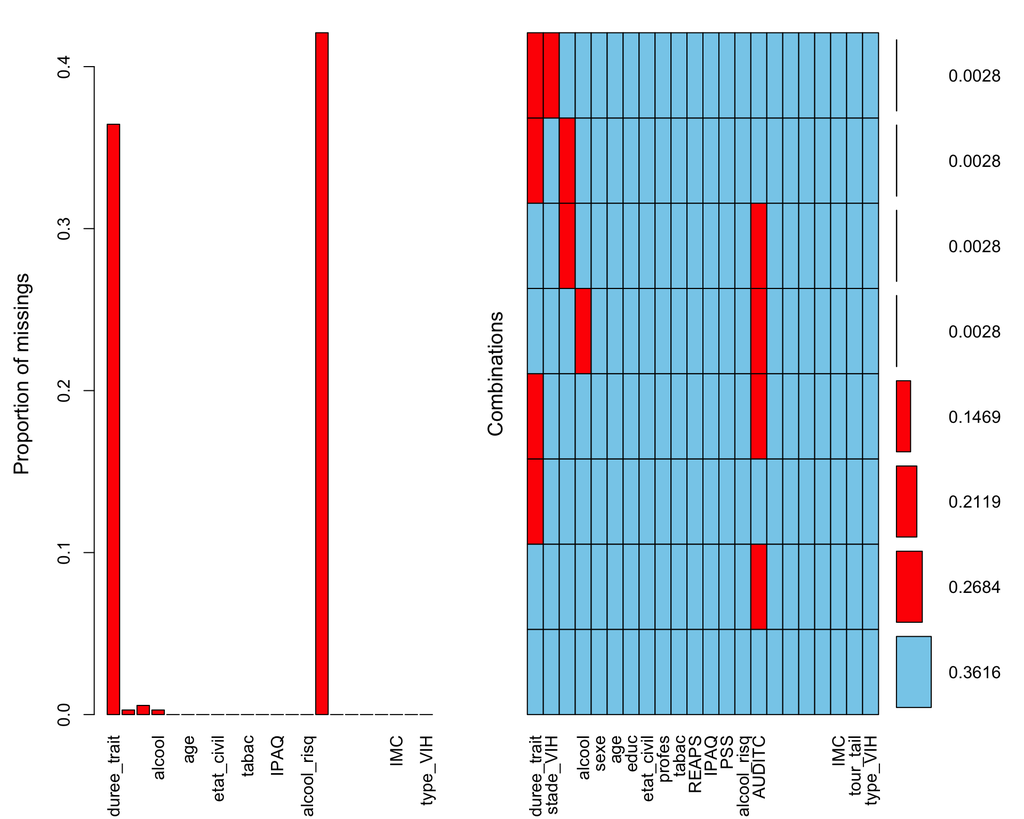

```r
# Visualisation graphique
aggr(vars_imputation, numbers = TRUE, prop = TRUE)
```

## 2.3 Imputation multiple

```r
meth <- mice::make.method(vars_imputation)

# Ne pas "imputer" les variables sans valeurs manquantes
no_miss <- names(which(colSums(is.na(vars_imputation)) == 0))
meth[no_miss] <- ""

imp_data <- mice(
  vars_imputation,
  m = 5,
  method = meth,
  maxit = 50,
  seed = 123
)
```

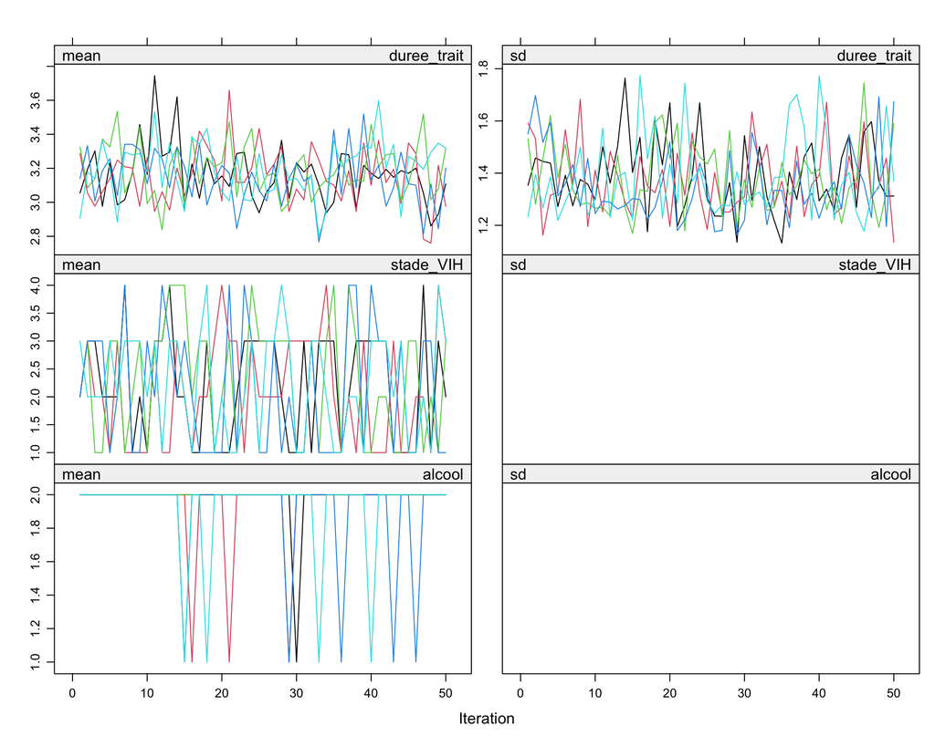

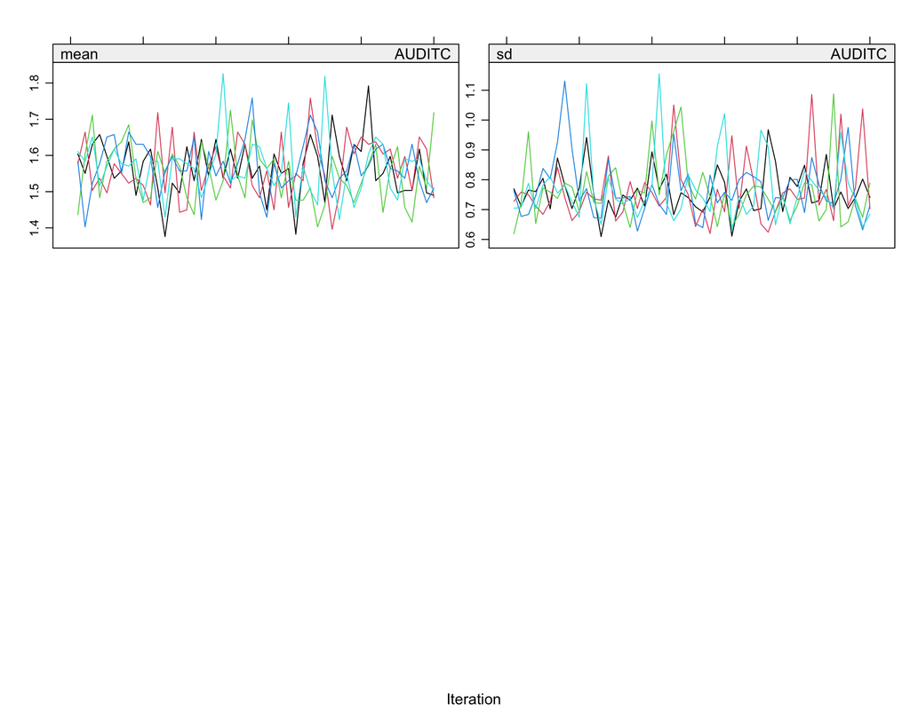

```r
# Vérification de la convergence
plot(imp_data)
```

```r
# extraction donnee finale
data_comp_imp <- mice::complete(imp_data)
data_comp <- data
data_comp[names(data_comp_imp)] <- data_comp_imp

# verification
colSums(is.na(data_comp_imp))
```

```
##  duree_trait    stade_VIH socioeco_cat       alcool         sexe          age
##            0            0            2            0            0            0
##         educ   etat_civil       profes        tabac        REAPS         IPAQ
##            0            0            0            0            0            0
##          PSS  alcool_risq       AUDITC     ATCD_HTA    ATCD_diab    ATCD_chol
##            0            0            0            0            0            0
##  ATCD_cardio          IMC    tour_tail     type_VIH
##            0            0            0            0
```

## 2.4 Catégorisations et transformations complémentaires (base finale)

### 2.4.1 Catégorisation de l’IMC et du tour de taille

```r
data_comp <- data_comp |>
  mutate(
    IMC_cat = case_when(
      IMC < 18.5 ~ "Insuffisance pondérale",
      IMC < 25 ~ "Normal",
      IMC < 30 ~ "Surpoids",
      IMC >= 30 ~ "Obésité",
      TRUE ~ NA_character_
    ),
    IMC_cat = factor(IMC_cat)
  )

# tour de taille

data_comp <- data_comp |>
  mutate(
    tour_tail_cat = case_when(
      sexe == "Homme" & tour_tail < 94 ~ "Normal",
      sexe == "Homme" & tour_tail >= 94 & tour_tail < 102 ~ "Risque modéré",
      sexe == "Homme" & tour_tail >= 102 ~ "Risque très élevé",
      sexe == "Femme" & tour_tail < 80 ~ "Normal",
      sexe == "Femme" & tour_tail >= 80 & tour_tail < 88 ~ "Risque modéré",
      sexe == "Femme" & tour_tail >= 88 ~ "Risque très élevé",
      TRUE ~ NA_character_
    )
  )
```

### 2.4.2 Catégorisation du score IPAQ

```r
data_comp <- data_comp |>
  mutate(
    IPAQ_cat = case_when(
      IPAQ < 600 ~ "Faible",
      IPAQ < 3000 ~ "Modérée",
      IPAQ >= 3000 ~ "Élevée",
      TRUE ~ NA_character_
    ),
    IPAQ_cat = factor(
      IPAQ_cat,
      levels = c("Faible","Modérée","Élevée")
    )
  )
```

### 2.4.3 Standardisation du score de stress perçu (PSS)

```r
data_comp <- data_comp |>
  mutate(
    PSS = as.numeric(scale(PSS))
  )
```

### 2.4.4 Catégorisation de l’âge

```r
data_comp <- data_comp |>
  mutate(
    age_cat = cut(
      age,
      breaks = c(18,30,40,50,60,100),   # inclure <18
      labels = c("18-29","30-39","40-49","50-59","≥60"),
      right = FALSE,
      include.lowest = TRUE
    ),
    age_cat = factor(
      age_cat,
      levels = c("18-29","30-39","40-49","50-59","≥60")
    )
  )
```

# 3. Construction des outcomes lipidiques

## 3.1 Définition de la dyslipidémie (seuils cliniques)

```r
data_comp <- data_comp |>
  mutate(
    hyperchol = ifelse(chol_total >= 2.0, 1, 0),
    ldl_eleve = ifelse(ldl >= 1.3, 1, 0),
    hypertrig = ifelse(triglycerides >= 1.5, 1, 0),
    hdl_bas = case_when(
      sexe == "Homme" & hdl < 0.40 ~ 1,
      sexe == "Femme" & hdl < 0.50 ~ 1,
      TRUE ~ 0
    )
  )

data_comp <- data_comp |>
  mutate(
    dyslipidemie = ifelse(
      hyperchol == 1 | ldl_eleve == 1 | hypertrig == 1 | hdl_bas == 1,
      1, 0
    )
  )

data_comp <- data_comp |>
  mutate(
    dyslipidemie = factor(
      dyslipidemie,
      levels = c(0,1),
      labels = c("Non","Oui")
    )
  )

tabyl(data_comp$dyslipidemie)
```

```
##  data_comp$dyslipidemie   n  percent
##                     Non 241 0.680791
##                     Oui 113 0.319209
```

## 3.2 Analyse en composantes principales (ACP) des lipides

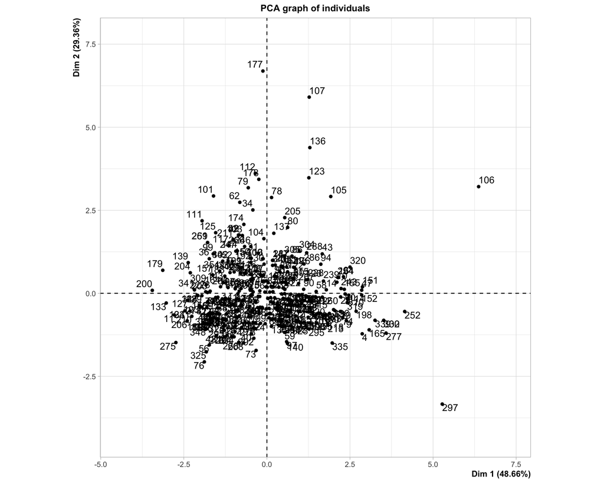

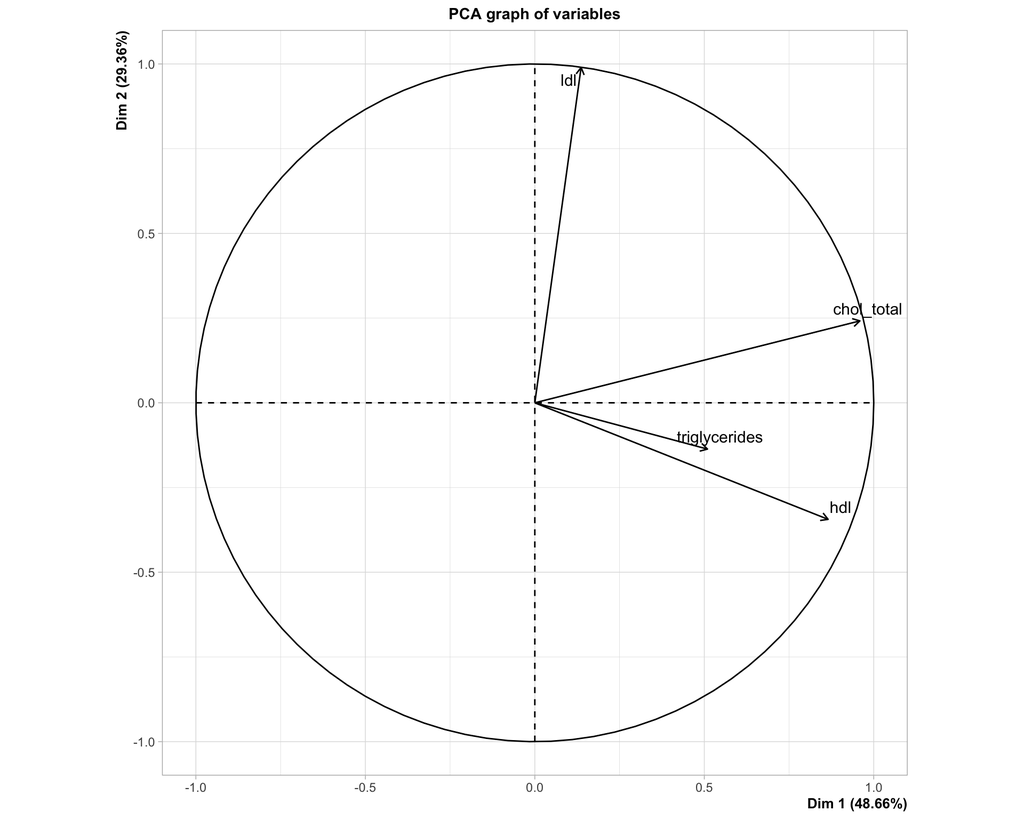

```r
lipides <- data_comp |>
  dplyr::select(chol_total, ldl, hdl, triglycerides)

idx_lipides_cc <- stats::complete.cases(lipides)
lipides_cc <- lipides[idx_lipides_cc, , drop = FALSE]

res_pca <- PCA(lipides_cc, scale.unit = TRUE, graph = TRUE)
```

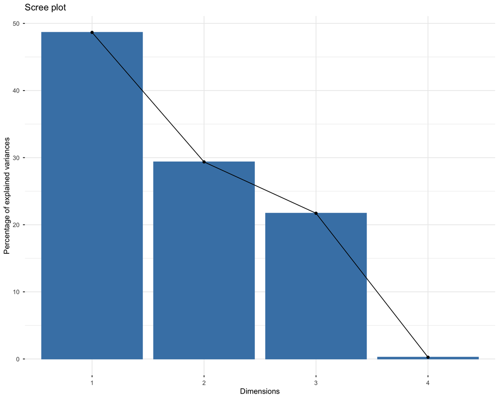

```r
fviz_eig(res_pca)
```

```r
#data_comp$score_lipidique <- NA_real_
data_comp$score_lipidique[idx_lipides_cc] <- res_pca$ind$coord[, 1]
```

## 3.3 Classification des profils lipidiques (K-means)

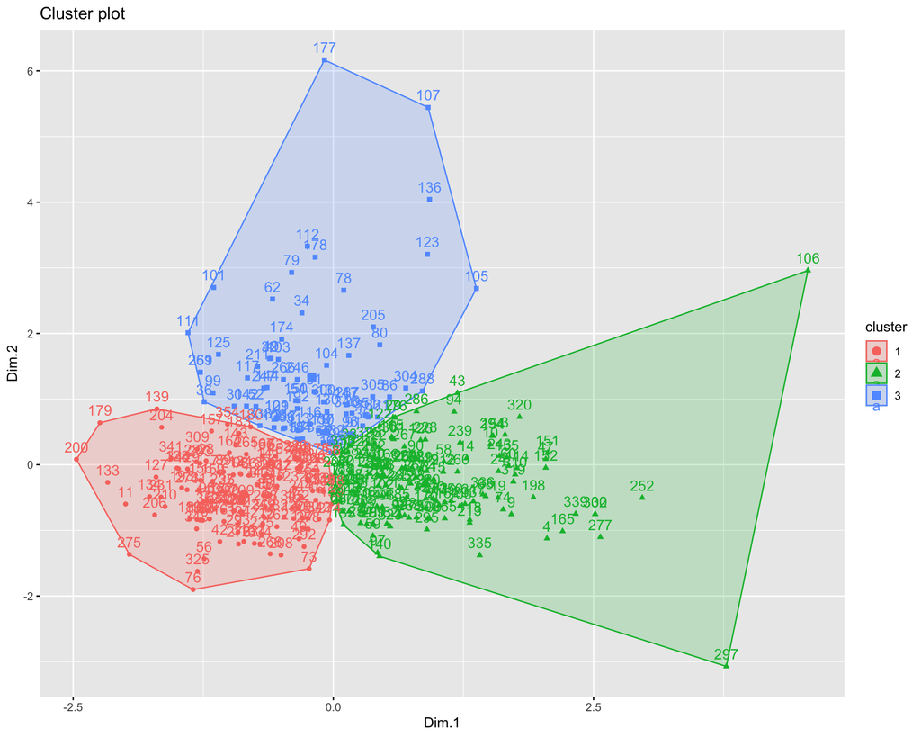

```r
set.seed(123)

km <- kmeans(res_pca$ind$coord[, 1:2, drop = FALSE], centers = 3)

data_comp$profil_lipidique <- NA_integer_
data_comp$profil_lipidique[idx_lipides_cc] <- km$cluster
data_comp$profil_lipidique <- factor(data_comp$profil_lipidique)

fviz_cluster(km, data = res_pca$ind$coord[, 1:2, drop = FALSE])
```

# 4. Analyse descriptive

## 4.1 Variables quantitatives

```r
data_comp |>
  dplyr::select(
    age,
    AUDITC,
    REAPS,
    IPAQ,
    PSS,
    IMC,
    tour_tail,
    duree_trait
  ) |>
  psych::describe() |>
  dplyr::select(n, mean, sd, median, min, max)
```

```
##               n   mean      sd median   min     max
## age         354  43.47   11.75  43.00 18.00   74.00
## AUDITC      354   2.19    1.83   1.00  1.00   12.00
## REAPS       354  36.08    6.15  36.00 21.00   50.00
## IPAQ        354 766.22 1039.54 396.00  0.00 8700.00
## PSS         354   0.00    1.00   0.08 -1.86    2.83
## IMC         354  28.50   27.50  24.97  1.47  421.44
## tour_tail   354  90.88   13.55  90.00 62.00  146.00
## duree_trait 354   3.15    1.39   3.00  0.00   11.00
```

## 4.2 Variables qualitatives

```r
tbl1 <- data_comp |>

  dplyr::select(

    # Outcome
    dyslipidemie,

    # Socio-demographiques
    sexe,
    age_cat,
    age,
    educ,
    etat_civil,
    profes,
    socioeco_cat,

    # Comportementales
    tabac,
    alcool,
    AUDITC,
    REAPS,

    IPAQ_cat,
    IPAQ,

    PSS,

    # Anthropométriques
    IMC_cat,
    IMC,

    tour_tail_cat,
    tour_tail,

    # VIH + clinique
    type_VIH,
    stade_VIH,

    ATCD_HTA,
    ATCD_diab,
    ATCD_chol,
    ATCD_cardio,

    # Thérapeutiques
    ligne_ARV,
    ARV,
    duree_trait

  ) |>

  # supprimer niveaux inutilisés
  mutate(
    across(where(is.factor), droplevels)
  ) |>

  tbl_summary(

    type = c(
      age,
      AUDITC,
      REAPS,
      IPAQ,
      PSS,
      IMC,
      tour_tail,
      duree_trait
    ) ~ "continuous2",

    statistic = list(

      all_categorical() ~ "{n} ({p}%)",

      all_continuous2() ~ c(
        "{mean} ({median}), {sd} ({min}-{max})",
        "{p25}-{p75}"
      )
    ),

    digits = all_continuous2() ~ 1,

    missing = "no",

    label = list(

      dyslipidemie ~ "Dyslipidémie",

      sexe ~ "Sexe",

      age_cat ~ "Groupe d'âge (ans)",
      age ~ "Âge",

      educ ~ "Niveau d'éducation",
      etat_civil ~ "Etat civil",
      profes ~ "Profession",
      socioeco_cat ~ "Statut socio-économique",

      tabac ~ "Tabagisme",
      alcool ~ "Consommation d'alcool",

      AUDITC ~ "Score AUDIT-C",

      REAPS ~ "Score alimentaire REAPS",

      IPAQ_cat ~ "Activité physique",
      IPAQ ~ "Score IPAQ (MET-min/semaine)",

      PSS ~ "Score de stress perçu",

      IMC_cat ~ "IMC (catégories)",
      IMC ~ "IMC",

      tour_tail_cat ~ "Tour de taille",
      tour_tail ~ "Tour de taille (cm)",

      type_VIH ~ "Type de VIH",
      stade_VIH ~ "Stade clinique VIH",

      ATCD_HTA ~ "ATCD d'HTA",
      ATCD_diab ~ "ATCD de diabète",
      ATCD_chol ~ "ATCD d'hypercholestérolémie",
      ATCD_cardio ~ "ATCD cardiovasculaire",

      ligne_ARV ~ "Ligne thérapeutique",
      ARV ~ "Protocole ARV",

      duree_trait ~ "Durée sous TAR (années)"
    )
  ) |>

  add_overall() |>

  bold_labels() |>

  modify_header(
    label ~ "**Variables**",
    stat_0 ~ "**Total (N={N})**"
  ) |>

  modify_caption(
    "**Tableau 1. Caractéristiques sociodémographiques, cliniques et thérapeutiques des PVVIH sous TAR suivis dans le projet MetaVIH, Bénin, 2024.**"
  )
tbl1 <- tbl1 |>
  modify_table_body(
    ~ .x |>
      dplyr::filter(

        # enlever unknown / inconnu
        !(
          row_type %in% c("level", "missing") &
            stringr::str_to_lower(
              stringr::str_trim(
                as.character(label)
              )
            ) %in% c("unknown", "inconnu")
        ),

        # enlever modalités à 0 (0%)
        !(
          row_type == "level" &
            stringr::str_detect(
              stat_0,
              "^0\\s*\\("
            )
        )
      )
  )

tbl1
```

**Tableau 1. Caractéristiques sociodémographiques, cliniques et thérapeutiques des PVVIH sous TAR suivis dans le projet MetaVIH, Bénin, 2024.**

| **Variables** | **Total (N=354)**<sup>1</sup> |
| --- | --- |
| Dyslipidémie |  |
| Non | 241 (68%) |
| Oui | 113 (32%) |
| Sexe |  |
| Homme | 118 (33%) |
| Femme | 236 (67%) |
| Groupe d'âge (ans) |  |
| 18-29 | 52 (15%) |
| 30-39 | 69 (19%) |
| 40-49 | 121 (34%) |
| 50-59 | 82 (23%) |
| ≥60 | 30 (8.5%) |
| Âge |  |
| Mean (Median), SD (Min-Max) | 43.5 (43.0), 11.8 (18.0-74.0) |
| Q1-Q3 | 36.0-52.0 |
| Niveau d'éducation |  |
| Aucun | 75 (21%) |
| Primaire | 94 (27%) |
| Secondaire | 135 (38%) |
| Universitaire | 50 (14%) |
| Etat civil |  |
| Jamais mariée | 67 (19%) |
| Mariée | 58 (16%) |
| Séparée/Divorcée | 44 (12%) |
| Veuve | 50 (14%) |
| Concubinage | 134 (38%) |
| Refuse de répondre | 1 (0.3%) |
| Profession |  |
| Employé de l’Etat | 19 (5.4%) |
| Employé du privé | 41 (12%) |

[output cut: 77 more lines]

<sup>1</sup> n (%)

## 4.3 Tests de normalité

### 4.3.1 Test de Shapiro-Wilk

```r
# Variables quantitatives
quant_vars <- c(
  "age", "AUDITC", "REAPS", "IPAQ", "PSS", "IMC", "duree_trait", "tour_tail", "hdl", "ldl", "triglycerides", "chol_total"
)

# Test de normalité Shapiro-Wilk pour chaque variable
# Note: avec des effectifs élevés, le test est très sensible; interpréter avec les graphiques.
cat("Regle: si p-value > 0.05, normalite non rejetee; sinon, normalite rejetee.\n")
```

```
## Regle: si p-value > 0.05, normalite non rejetee; sinon, normalite rejetee.
```

```r
for (var in quant_vars) {
  cat("\n--- Test de normalité pour :", var, "---\n")
  x <- na.omit(data_comp |> dplyr::select(all_of(var)) |> pull())
  if(length(x) >= 3){  # shapiro.test nécessite au moins 3 valeurs
    res <- shapiro.test(x)
    print(res)

    if (is.finite(res$p.value) && res$p.value > 0.05) {
      cat("Commentaire: normalite non rejetee (p-value > 0.05). Distribution compatible avec la normalite.\n")
    } else {
      cat("Commentaire: normalite rejetee (p-value <= 0.05). Distribution non normale; envisager mediane/IQR, tests non parametriques ou transformation.\n")
    }
  } else {
    cat("Pas assez de données pour tester la normalité.\n")
  }
}
```

```
##
## --- Test de normalité pour : age ---
##
##  Shapiro-Wilk normality test
##
## data:  x
## W = 0.99036, p-value = 0.02015
##
## Commentaire: normalite rejetee (p-value <= 0.05). Distribution non normale; envisager mediane/IQR, tests non parametriques ou transformation.
##
## --- Test de normalité pour : AUDITC ---
##
##  Shapiro-Wilk normality test
##
## data:  x
## W = 0.6859, p-value < 2.2e-16
##
## Commentaire: normalite rejetee (p-value <= 0.05). Distribution non normale; envisager mediane/IQR, tests non parametriques ou transformation.
##
## --- Test de normalité pour : REAPS ---
##
##  Shapiro-Wilk normality test
##
## data:  x
## W = 0.98566, p-value = 0.001396
##
## Commentaire: normalite rejetee (p-value <= 0.05). Distribution non normale; envisager mediane/IQR, tests non parametriques ou transformation.
##
## --- Test de normalité pour : IPAQ ---
##
##  Shapiro-Wilk normality test
##
## data:  x
## W = 0.68002, p-value < 2.2e-16
##
## Commentaire: normalite rejetee (p-value <= 0.05). Distribution non normale; envisager mediane/IQR, tests non parametriques ou transformation.
##
## --- Test de normalité pour : PSS ---
##
##  Shapiro-Wilk normality test
```

[output cut: 53 more lines]

```
##  Shapiro-Wilk normality test
##
## data:  x
## W = 0.78018, p-value < 2.2e-16
##
## Commentaire: normalite rejetee (p-value <= 0.05). Distribution non normale; envisager mediane/IQR, tests non parametriques ou transformation.
##
## --- Test de normalité pour : chol_total ---
##
##  Shapiro-Wilk normality test
##
## data:  x
## W = 0.98346, p-value = 0.0004361
##
## Commentaire: normalite rejetee (p-value <= 0.05). Distribution non normale; envisager mediane/IQR, tests non parametriques ou transformation.
```

### 4.3.2 Histogrammes

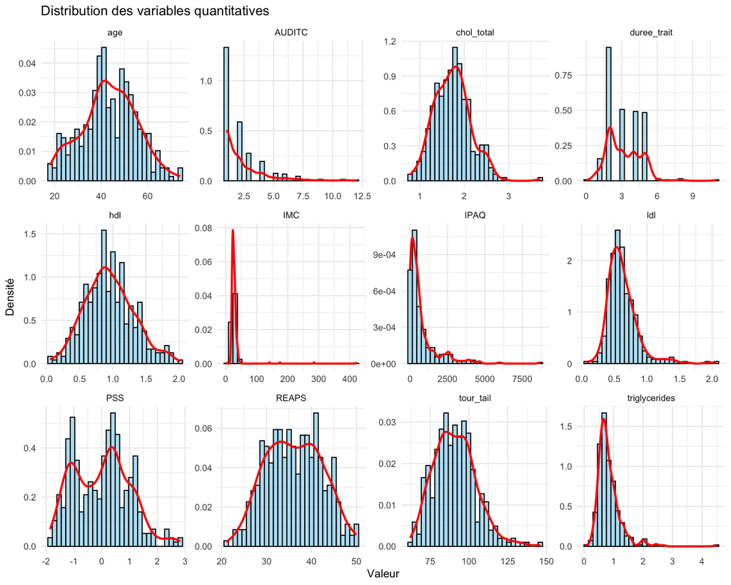

```r
# Variables quantitatives
quant_vars <- c(
  "age", "AUDITC", "REAPS", "IPAQ", "PSS", "IMC", "duree_trait", "tour_tail", "hdl", "ldl", "triglycerides", "chol_total"
)

# Transformation en format long pour ggplot
data_long <- data_comp |>
  dplyr::select(all_of(quant_vars)) |>
  pivot_longer(
    cols = everything(),
    names_to = "Variable",
    values_to = "Valeur")

# Histogramme avec densité
ggplot(data_long, aes(x = Valeur)) +
  geom_histogram(aes(y = ..density..), bins = 30, fill = "skyblue", color = "black", alpha = 0.6) +
  geom_density(color = "red", size = 1) +
  facet_wrap(~ Variable, scales = "free") +
  theme_minimal() +
  labs(title = "Distribution des variables quantitatives", x = "Valeur", y = "Densité")
```

### 4.3.3 QQ-plots

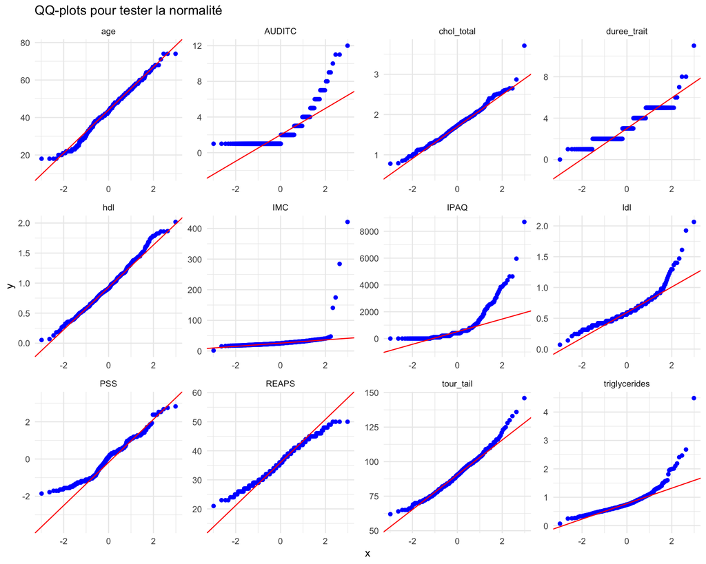

```r
ggplot(data_long, aes(sample = Valeur)) +
  stat_qq(color = "blue") +
  stat_qq_line(color = "red") +
  facet_wrap(~ Variable, scales = "free") +
  theme_minimal() +
  labs(title = "QQ-plots pour tester la normalité")
```

**Conclusion Generale :**

L’age, hdl, cholesterol total suivent une distribution normale (selon les QQ-plots), avec quelques violations aux extremites.

## 4.4 Tableau descriptif bivarié (Tableau 2)

```r
tbl2 <- data_comp |>

  dplyr::select(

    dyslipidemie,

    # Socio-demographiques
    sexe,
    age_cat,
    age,
    educ,
    etat_civil,
    profes,
    socioeco_cat,

    # Comportementales
    tabac,
    alcool,
    AUDITC,
    REAPS,

    IPAQ,

    PSS,

    # Anthropométriques
    IMC,

    tour_tail,

    # VIH + clinique
    stade_VIH,

    ATCD_HTA,
    ATCD_diab,
    ATCD_chol,
    ATCD_cardio,

    # Thérapeutiques
    ligne_ARV,
    duree_trait
  ) |>

  mutate(
    across(where(is.factor), droplevels)
  ) |>

  tbl_summary(

    by = dyslipidemie,

    type = c(
      age,
      AUDITC,
      REAPS,
      IPAQ,
      PSS,
      IMC,
      tour_tail,
      duree_trait
    ) ~ "continuous2",

    statistic = list(

      all_categorical() ~ "{n} ({p}%)",

      all_continuous2() ~ c(
        "{mean} ({median}), {sd} ({min}-{max})",
        "{p25}-{p75}"
      )
    ),

    digits = all_continuous2() ~ 1,

    missing = "no",

    label = list(

      sexe ~ "Sexe",

      age_cat ~ "Groupe d'âge (ans)",
      age ~ "Âge",

      educ ~ "Niveau d'éducation",
      etat_civil ~ "Etat civil",
      profes ~ "Profession",
      socioeco_cat ~ "Statut socio-économique",

      tabac ~ "Tabagisme",
      alcool ~ "Consommation d'alcool",

      AUDITC ~ "Score AUDIT-C",

      REAPS ~ "Score alimentaire REAPS",

      IPAQ ~ "Score IPAQ (MET-min/semaine)",

      PSS ~ "Score de stress perçu",

      IMC ~ "IMC",

      tour_tail ~ "Tour de taille (cm)",

      stade_VIH ~ "Stade clinique VIH",

      ATCD_HTA ~ "ATCD d'HTA",
      ATCD_diab ~ "ATCD de diabète",
      ATCD_chol ~ "ATCD d'hypercholestérolémie",
      ATCD_cardio ~ "ATCD cardiovasculaire",

      ligne_ARV ~ "Ligne thérapeutique",

      duree_trait ~ "Durée sous TAR (années)"
    )
  ) |>

  add_overall() |>

  # Tests statistiques
  add_p(
    test = list(

      all_continuous2() ~ "wilcox.test",

      all_categorical() ~ "chisq.test"
    ),

    pvalue_fun = ~style_pvalue(.x, digits = 3)
  ) |>

  bold_labels() |>

  bold_p(t = 0.05) |>

  modify_header(
    label ~ "**Variables**",
    stat_0 ~ "**Total**",
    stat_1 ~ "**Sans dyslipidémie**",
    stat_2 ~ "**Avec dyslipidémie**",
    p.value ~ "**p**"
  ) |>

  modify_caption(
    "**Tableau 2. Comparaison des caractéristiques sociodémographiques, cliniques et thérapeutiques selon la présence d'une dyslipidémie chez les PVVIH sous TAR suivis dans le projet MetaVIH, Bénin, 2024.**"
  )

# Nettoyage final

tbl2 <- tbl2 |>
  modify_table_body(
    ~ .x |>
      filter(

        # enlever unknown
        !(
          row_type %in% c("level", "missing") &
            str_to_lower(
              str_trim(
                as.character(label)
              )
            ) %in% c("unknown", "inconnu")
        ),

        # enlever 0%
        !(
          row_type == "level" &
            str_detect(
              stat_0,
              "^0\\s*\\("
            )
        )
      )
  )

tbl2
```

**Tableau 2. Comparaison des caractéristiques sociodémographiques, cliniques et thérapeutiques selon la présence d’une dyslipidémie chez les PVVIH sous TAR suivis dans le projet MetaVIH, Bénin, 2024.**

| **Variables** | **Total**<sup>1</sup> | **Sans dyslipidémie**<sup>1</sup> | **Avec dyslipidémie**<sup>1</sup> | **p**<sup>2</sup> |
| --- | --- | --- | --- | --- |
| Sexe |  |  |  | 0.014 |
| Homme | 118 (33%) | 91 (38%) | 27 (24%) |  |
| Femme | 236 (67%) | 150 (62%) | 86 (76%) |  |
| Groupe d'âge (ans) |  |  |  | 0.068 |
| 18-29 | 52 (15%) | 43 (18%) | 9 (8.0%) |  |
| 30-39 | 69 (19%) | 46 (19%) | 23 (20%) |  |
| 40-49 | 121 (34%) | 84 (35%) | 37 (33%) |  |
| 50-59 | 82 (23%) | 48 (20%) | 34 (30%) |  |
| ≥60 | 30 (8.5%) | 20 (8.3%) | 10 (8.8%) |  |
| Âge |  |  |  | 0.019 |
| Mean (Median), SD (Min-Max) | 43.5 (43.0), 11.8 (18.0-74.0) | 42.5 (42.0), 12.0 (18.0-74.0) | 45.5 (47.0), 11.1 (18.0-74.0) |  |
| Q1-Q3 | 36.0-52.0 | 35.0-51.0 | 39.0-53.0 |  |
| Niveau d'éducation |  |  |  | 0.135 |
| Aucun | 75 (21%) | 48 (20%) | 27 (24%) |  |
| Primaire | 94 (27%) | 64 (27%) | 30 (27%) |  |
| Secondaire | 135 (38%) | 88 (37%) | 47 (42%) |  |
| Universitaire | 50 (14%) | 41 (17%) | 9 (8.0%) |  |
| Etat civil |  |  |  | 0.321 |
| Jamais mariée | 67 (19%) | 47 (20%) | 20 (18%) |  |
| Mariée | 58 (16%) | 34 (14%) | 24 (21%) |  |
| Séparée/Divorcée | 44 (12%) | 28 (12%) | 16 (14%) |  |
| Veuve | 50 (14%) | 32 (13%) | 18 (16%) |  |
| Concubinage | 134 (38%) | 99 (41%) | 35 (31%) |  |
| Refuse de répondre | 1 (0.3%) | 1 (0.4%) | 0 (0%) |  |
| Profession |  |  |  | 0.634 |
| Employé de l’Etat | 19 (5.4%) | 12 (5.0%) | 7 (6.2%) |  |
| Employé du privé | 41 (12%) | 31 (13%) | 10 (8.8%) |  |
| Indépendant | 251 (71%) | 166 (69%) | 85 (75%) |  |
| Etudiant | 10 (2.8%) | 8 (3.3%) | 2 (1.8%) |  |
| Maîtresse de maison/Retraitée/Chômeur/Invalide | 31 (8.8%) | 22 (9.1%) | 9 (8.0%) |  |

[output cut: 52 more lines]

<sup>1</sup> n (%)  
<sup>2</sup> Pearson’s Chi-squared test; Wilcoxon rank sum test

# 5. Modélisation statistique

## 5.1 Régression logistique — analyses préliminaires

```r
data_comp$dyslipidemie_num <- ifelse(data_comp$dyslipidemie == "Oui", 1, 0)
```

```r
Data_logit <- data_comp |>
  dplyr::select(
    dyslipidemie_num,
    age, age_cat, sexe, socioeco_cat,
    tabac, alcool, AUDITC,
    REAPS,
    IPAQ, PSS,
    IMC,
    tour_tail,
    stade_VIH,
    ATCD_HTA, ATCD_diab, ATCD_chol, ATCD_cardio,
    ligne_ARV, duree_trait
  ) |>
  na.omit()
```

```r
# model complet

model_full <- glm(dyslipidemie_num ~ age + sexe + socioeco_cat +
    tabac + alcool + REAPS + IPAQ + PSS + IMC + tour_tail + ATCD_HTA + ATCD_diab +
    duree_trait,
    family = binomial,
    data = Data_logit)
summary(model_full)
```

```
##
## Call:
## glm(formula = dyslipidemie_num ~ age + sexe + socioeco_cat +
##     tabac + alcool + REAPS + IPAQ + PSS + IMC + tour_tail + ATCD_HTA +
##     ATCD_diab + duree_trait, family = binomial, data = Data_logit)
##
## Coefficients:
##                     Estimate Std. Error z value Pr(>|z|)
## (Intercept)       -1.759e-01  1.729e+00  -0.102  0.91895
## age                1.085e-02  1.603e-02   0.677  0.49836
## sexeFemme          1.269e+00  4.285e-01   2.961  0.00306 **
## socioeco_catÉlevé  1.162e-01  5.690e-01   0.204  0.83821
## socioeco_catMoyen  2.642e-01  3.456e-01   0.764  0.44463
## tabacNon          -4.571e-01  8.362e-01  -0.547  0.58462
## alcoolOui          1.822e-01  5.165e-01   0.353  0.72434
## REAPS             -3.223e-02  2.710e-02  -1.189  0.23437
## IPAQ              -8.701e-06  1.603e-04  -0.054  0.95670
## PSS               -5.737e-02  1.592e-01  -0.360  0.71851
## IMC               -1.661e-02  2.424e-02  -0.685  0.49314
## tour_tail         -2.197e-03  1.445e-02  -0.152  0.87912
## ATCD_HTAOui        2.424e-01  3.904e-01   0.621  0.53467
## ATCD_diabOui       2.586e+00  1.200e+00   2.155  0.03118 *
## duree_trait       -6.974e-02  1.084e-01  -0.643  0.52013
## ---
## Signif. codes:  0 '***' 0.001 '**' 0.01 '*' 0.05 '.' 0.1 ' ' 1
##
## (Dispersion parameter for binomial family taken to be 1)
##
##     Null deviance: 279.80  on 223  degrees of freedom
## Residual deviance: 259.62  on 209  degrees of freedom
## AIC: 289.62
##
## Number of Fisher Scoring iterations: 7
```

```r
# Sélection par AIC (stepwise backward)
mod_aic <- step(
  model_full,
  direction = "backward"
)
```

```
## Start:  AIC=289.62
## dyslipidemie_num ~ age + sexe + socioeco_cat + tabac + alcool +
##     REAPS + IPAQ + PSS + IMC + tour_tail + ATCD_HTA + ATCD_diab +
##     duree_trait
##
##                Df Deviance    AIC
## - socioeco_cat  2   260.23 286.23
## - IPAQ          1   259.63 287.63
## - tour_tail     1   259.64 287.64
## - alcool        1   259.75 287.75
## - PSS           1   259.75 287.75
## - tabac         1   259.91 287.91
## - ATCD_HTA      1   260.00 288.00
## - duree_trait   1   260.05 288.05
## - age           1   260.08 288.08
## - REAPS         1   261.06 289.06
## <none>              259.62 289.62
## - IMC           1   262.01 290.01
## - ATCD_diab     1   266.05 294.05
## - sexe          1   269.38 297.38
##
## Step:  AIC=286.23
## dyslipidemie_num ~ age + sexe + tabac + alcool + REAPS + IPAQ +
##     PSS + IMC + tour_tail + ATCD_HTA + ATCD_diab + duree_trait
##
##               Df Deviance    AIC
## - IPAQ         1   260.23 284.23
## - tour_tail    1   260.25 284.25
## - PSS          1   260.35 284.35
## - alcool       1   260.40 284.40
## - tabac        1   260.42 284.42
## - ATCD_HTA     1   260.61 284.61
## - age          1   260.63 284.63
## - duree_trait  1   260.68 284.68
## - REAPS        1   261.62 285.62
## <none>             260.23 286.23
## - IMC          1   262.50 286.50
## - ATCD_diab    1   266.72 290.72
## - sexe         1   269.70 293.70
##
```

[output cut: 106 more lines]

```
##             Df Deviance    AIC
## - REAPS      1   262.95 270.95
## <none>           261.85 271.85
## - IMC        1   264.21 272.21
## - ATCD_diab  1   270.03 278.03
## - sexe       1   270.85 278.85
##
## Step:  AIC=270.95
## dyslipidemie_num ~ sexe + IMC + ATCD_diab
##
##             Df Deviance    AIC
## <none>           262.95 270.95
## - IMC        1   265.20 271.20
## - ATCD_diab  1   270.65 276.65
## - sexe       1   271.08 277.08
```

```r
mod_final <- glm(dyslipidemie_num ~ sexe + age + REAPS + IMC + ATCD_diab,
                 family = binomial,
                data = Data_logit)
summary(mod_final)
```

```
##
## Call:
## glm(formula = dyslipidemie_num ~ sexe + age + REAPS + IMC + ATCD_diab,
##     family = binomial, data = Data_logit)
##
## Coefficients:
##              Estimate Std. Error z value Pr(>|z|)
## (Intercept)  -0.56664    1.15961  -0.489  0.62509
## sexeFemme     1.10105    0.37781   2.914  0.00357 **
## age           0.01031    0.01487   0.693  0.48821
## REAPS        -0.03108    0.02642  -1.176  0.23943
## IMC          -0.01594    0.01987  -0.802  0.42242
## ATCD_diabOui  2.67691    1.15814   2.311  0.02081 *
## ---
## Signif. codes:  0 '***' 0.001 '**' 0.01 '*' 0.05 '.' 0.1 ' ' 1
##
## (Dispersion parameter for binomial family taken to be 1)
##
##     Null deviance: 279.80  on 223  degrees of freedom
## Residual deviance: 261.37  on 218  degrees of freedom
## AIC: 273.37
##
## Number of Fisher Scoring iterations: 6
```

```r
# OR
exp(coef(mod_final))
```

```
##  (Intercept)    sexeFemme          age        REAPS          IMC ATCD_diabOui
##    0.5674279    3.0073163    1.0103585    0.9693952    0.9841866   14.5400326
```

```r
# IC95
exp(confint(mod_final))
```

```
##                   2.5 %     97.5 %
## (Intercept)  0.06074607   5.926736
## sexeFemme    1.47380327   6.542963
## age          0.98147221   1.040674
## REAPS        0.91976000   1.020513
## IMC          0.93631701   1.002044
## ATCD_diabOui 2.03945009 298.869553
```

```r
library(broom)

broom::tidy(
  mod_final,
  exponentiate = TRUE,
  conf.int = TRUE
)
```

```
## # A tibble: 6 × 7
##   term         estimate std.error statistic p.value conf.low conf.high
##   <chr>           <dbl>     <dbl>     <dbl>   <dbl>    <dbl>     <dbl>
## 1 (Intercept)     0.567    1.16      -0.489 0.625     0.0607      5.93
## 2 sexeFemme       3.01     0.378      2.91  0.00357   1.47        6.54
## 3 age             1.01     0.0149     0.693 0.488     0.981       1.04
## 4 REAPS           0.969    0.0264    -1.18  0.239     0.920       1.02
## 5 IMC             0.984    0.0199    -0.802 0.422     0.936       1.00
## 6 ATCD_diabOui   14.5      1.16       2.31  0.0208    2.04      299.
```

```r
table_summary <- broom::tidy(
  mod_final,
  exponentiate = TRUE,
  conf.int = TRUE
) |>
  dplyr::mutate(
    OR = sprintf("%.2f", estimate),
    IC95 = sprintf("%.2f - %.2f", conf.low, conf.high),
    p_value = ifelse(p.value < 0.001, "<0.001", round(p.value, 3))
  ) |>
  dplyr::select(term, OR, IC95, p_value)

table_summary
```

```
## # A tibble: 6 × 4
##   term         OR    IC95          p_value
##   <chr>        <chr> <chr>           <dbl>
## 1 (Intercept)  0.57  0.06 - 5.93     0.625
## 2 sexeFemme    3.01  1.47 - 6.54     0.004
## 3 age          1.01  0.98 - 1.04     0.488
## 4 REAPS        0.97  0.92 - 1.02     0.239
## 5 IMC          0.98  0.94 - 1.00     0.422
## 6 ATCD_diabOui 14.54 2.04 - 298.87   0.021
```

```r
# Verification de la colinearite
car::vif(mod_final)
```

```
##      sexe       age     REAPS       IMC ATCD_diab
##  1.097400  1.094819  1.109536  1.014245  1.033859
```

```r
## Calibration (Hosmer-Lemeshow)
library(ResourceSelection)
hoslem.test(
  mod_final$y,
  fitted(mod_final)
)
```

```
##
##  Hosmer and Lemeshow goodness of fit (GOF) test
##
## data:  mod_final$y, fitted(mod_final)
## X-squared = 5.823, df = 8, p-value = 0.667
```

```r
library(pROC)
roc_obj <- roc(
  Data_logit$dyslipidemie_num,
  fitted(mod_final)
)

auc(roc_obj)
```

```
## Area under the curve: 0.6397
```

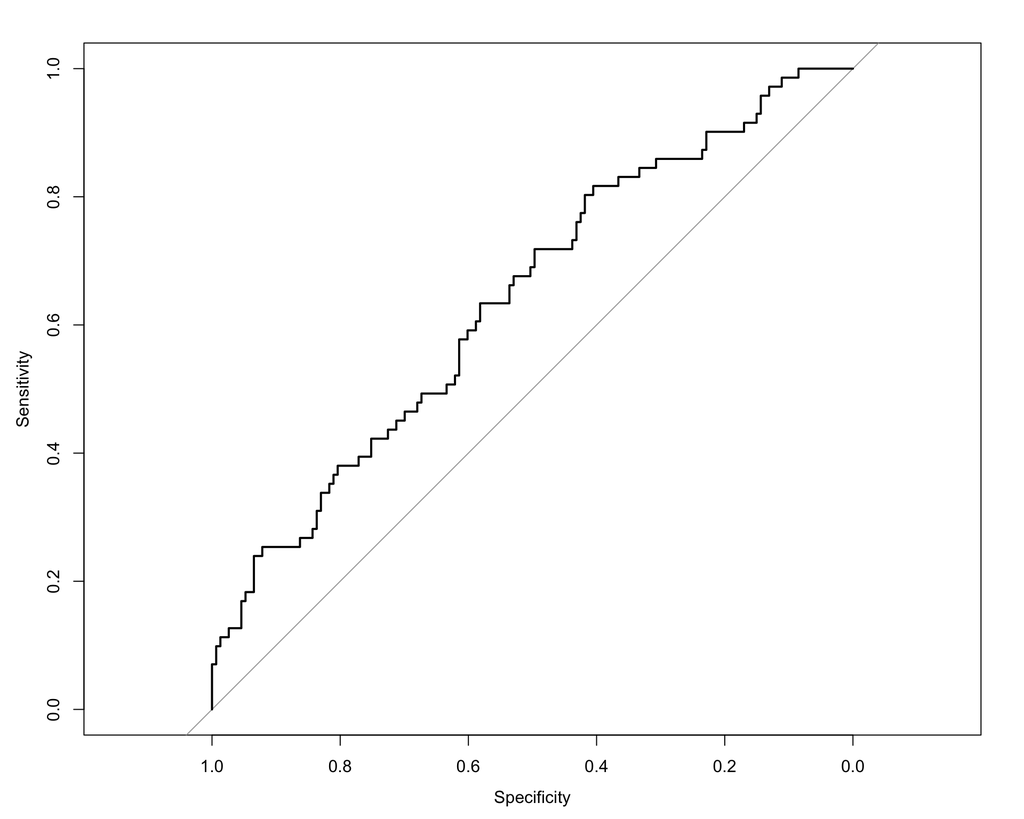

```r
plot(roc_obj)
```

```r
# Tableau modèle initial

tbl_init <- tbl_regression(
  model_full,
  exponentiate = TRUE
)

# Tableau modèle final

tbl_final <- tbl_regression(
  mod_final,
  exponentiate = TRUE
)

# Fusion

tbl2 <- tbl_merge(
  tbls = list(
    tbl_init,
    tbl_final
  ),

  tab_spanner = c(
    "**Modèle initial**",
    "**Modèle final**"
  )
) |>

  bold_labels() |>

  modify_caption(
    "**Tableau 2. Facteurs associés à la dyslipidémie chez les PVVIH sous traitement antirétroviral suivis dans le projet MetaVIH, Bénin, 2024.**"
  )

tbl2
```

**Tableau 2. Facteurs associés à la dyslipidémie chez les PVVIH sous traitement antirétroviral suivis dans le projet MetaVIH, Bénin, 2024.**

| **Characteristic** | **Modèle initial** **OR** | **Modèle initial** **95% CI** | **Modèle initial** **p-value** | **Modèle final** **OR** | **Modèle final** **95% CI** | **Modèle final** **p-value** |
| --- | --- | --- | --- | --- | --- | --- |
| age | 1.01 | 0.98, 1.04 | 0.5 | 1.01 | 0.98, 1.04 | 0.5 |
| sexe |  |  |  |  |  |  |
| Homme | — | — |  | — | — |  |
| Femme | 3.56 | 1.58, 8.59 | 0.003 | 3.01 | 1.47, 6.54 | 0.004 |
| socioeco_cat |  |  |  |  |  |  |
| Bas | — | — |  |  |  |  |
| Élevé | 1.12 | 0.35, 3.37 | 0.8 |  |  |  |
| Moyen | 1.30 | 0.67, 2.60 | 0.4 |  |  |  |
| tabac |  |  |  |  |  |  |
| Oui | — | — |  |  |  |  |
| Non | 0.63 | 0.13, 3.81 | 0.6 |  |  |  |
| alcool |  |  |  |  |  |  |
| Non | — | — |  |  |  |  |
| Oui | 1.20 | 0.45, 3.48 | 0.7 |  |  |  |
| REAPS | 0.97 | 0.92, 1.02 | 0.2 | 0.97 | 0.92, 1.02 | 0.2 |
| IPAQ | 1.00 | 1.00, 1.00 | >0.9 |  |  |  |
| PSS | 0.94 | 0.69, 1.29 | 0.7 |  |  |  |
| IMC | 0.98 | 0.91, 1.00 | 0.5 | 0.98 | 0.94, 1.00 | 0.4 |
| tour_tail | 1.00 | 0.97, 1.03 | 0.9 |  |  |  |
| ATCD_HTA |  |  |  |  |  |  |
| Non | — | — |  |  |  |  |
| Oui | 1.27 | 0.58, 2.73 | 0.5 |  |  |  |
| ATCD_diab |  |  |  |  |  |  |
| Non | — | — |  | — | — |  |
| Oui | 13.3 | 1.72, 288 | 0.031 | 14.5 | 2.04, 299 | 0.021 |
| duree_trait | 0.93 | 0.75, 1.15 | 0.5 |  |  |  |

Abbreviations: CI = Confidence Interval, OR = Odds Ratio

## 5.2 Modèles de médiation (package mediation et SEM)

```r
## Modele de mediation

library(mediation)
library(dplyr)

Data_med <- data_comp |>
  dplyr::select(
    dyslipidemie_num,
    IMC, tour_tail,
    REAPS,
    age, sexe,
    tabac, alcool,
    IPAQ, PSS,
    ATCD_HTA, ATCD_diab,
    ARV, duree_trait
  ) |>
  mutate(dyslipidemie = dyslipidemie_num,
         Tour_taille = tour_tail)
```

```r
colSums(is.na(Data_med))
```

```
## dyslipidemie_num              IMC        tour_tail            REAPS
##                0                0                0                0
##              age             sexe            tabac           alcool
##                0                0                0                0
##             IPAQ              PSS         ATCD_HTA        ATCD_diab
##                0                0                0                0
##              ARV      duree_trait     dyslipidemie      Tour_taille
##                0                0                0                0
```

```r
#table(Data_med$dyslipidemie_num)

Data_med <- Data_med |>
  dplyr::mutate(
    sexe = ifelse(sexe == "Homme", 1, 0),
    tabac = ifelse(tabac == "Oui", 1, 0),
    alcool = ifelse(alcool == "Oui", 1, 0),
    ATCD_HTA = ifelse(ATCD_HTA == "Oui", 1, 0),
    ATCD_diab = ifelse(ATCD_diab == "Oui", 1, 0)
  )

Data_med <- Data_med |>
  dplyr::mutate(
    ARV = ifelse(
      ARV == "TDF-3TC-DTG",
      0,
      1
    )
  )
```

```r
str(Data_med)
```

```
## tibble [354 × 16] (S3: tbl_df/tbl/data.frame)
##  $ dyslipidemie_num: num [1:354] 0 0 1 1 0 0 0 0 1 1 ...
##  $ IMC             : num [1:354] 27.4 29 27.3 28.6 26.5 ...
##  $ tour_tail       : num [1:354] 92 102 100 94 98 110 90 101 84 92 ...
##  $ REAPS           : num [1:354] 38 38 27 37 36 39 44 36 36 30 ...
##  $ age             : num [1:354] 27 34 56 55 37 40 54 41 28 33 ...
##  $ sexe            : num [1:354] 0 0 0 0 0 0 1 0 1 0 ...
##  $ tabac           : num [1:354] 0 0 0 0 0 0 0 0 0 0 ...
##  $ alcool          : num [1:354] 1 1 1 1 1 1 1 1 1 1 ...
##  $ IPAQ            : num [1:354] 4350 636 396 198 132 298 438 33 299 396 ...
##  $ PSS             : num [1:354] -0.964 -0.37 -1.113 0.299 -1.187 ...
##  $ ATCD_HTA        : num [1:354] 0 0 0 1 0 0 1 1 1 0 ...
##  $ ATCD_diab       : num [1:354] 0 0 0 0 0 0 0 0 0 0 ...
##  $ ARV             : num [1:354] 0 0 0 0 0 0 0 0 0 0 ...
##  $ duree_trait     : num [1:354] 3 2 5 5 2 4 2 5 2 4 ...
##  $ dyslipidemie    : num [1:354] 0 0 1 1 0 0 0 0 1 1 ...
##  $ Tour_taille     : num [1:354] 92 102 100 94 98 110 90 101 84 92 ...
```

```r
model.M <- lm(
  REAPS ~ PSS +
    age + sexe + tabac +
    IPAQ + IMC +
    ATCD_HTA + duree_trait,
  data = Data_med
)

model.M
```

```
##
## Call:
## lm(formula = REAPS ~ PSS + age + sexe + tabac + IPAQ + IMC +
##     ATCD_HTA + duree_trait, data = Data_med)
##
## Coefficients:
## (Intercept)          PSS          age         sexe        tabac         IPAQ
##   3.401e+01    1.615e-02    9.820e-02   -2.273e+00   -7.640e-01    9.019e-05
##         IMC     ATCD_HTA  duree_trait
##  -1.845e-03    2.827e-02   -4.449e-01
```

```r
model.Y <- glm(
  dyslipidemie ~ PSS + REAPS +
    age + sexe + tabac +
    IPAQ + IMC +
    ATCD_HTA + duree_trait,
  family = binomial,
  data = Data_med
)

model.Y
```

```
##
## Call:  glm(formula = dyslipidemie ~ PSS + REAPS + age + sexe + tabac +
##     IPAQ + IMC + ATCD_HTA + duree_trait, family = binomial, data = Data_med)
##
## Coefficients:
## (Intercept)          PSS        REAPS          age         sexe        tabac
##  -1.406e+00   -5.944e-02    8.373e-04    2.018e-02   -7.684e-01    3.446e-01
##        IPAQ          IMC     ATCD_HTA  duree_trait
##  -8.736e-05   -3.911e-03    4.553e-01    8.507e-03
##
## Degrees of Freedom: 353 Total (i.e. Null);  344 Residual
## Null Deviance:       443.4
## Residual Deviance: 427.3     AIC: 447.3
```

```r
library(mediation)

med.out <- mediation::mediate(
  model.M,
  model.Y,
  treat = "PSS",
  mediator = "REAPS",
  boot = TRUE,
  sims = 500
)

summary(med.out)
```

```
##
## Causal Mediation Analysis
##
## Nonparametric Bootstrap Confidence Intervals with the Percentile Method
##
##                             Estimate 95% CI Lower 95% CI Upper p-value
## ACME (control)            2.8095e-06  -2.6337e-03   3.2351e-03   0.984
## ACME (treated)            2.7528e-06  -2.5018e-03   3.0730e-03   0.984
## ADE (control)            -1.2225e-02  -5.5235e-02   4.1318e-02   0.644
## ADE (treated)            -1.2225e-02  -5.5282e-02   4.1320e-02   0.644
## Total Effect             -1.2222e-02  -5.6343e-02   4.1362e-02   0.652
## Prop. Mediated (control) -2.2988e-04  -5.6685e-01   3.9167e-01   0.964
## Prop. Mediated (treated) -2.2524e-04  -5.5970e-01   3.9302e-01   0.964
## ACME (average)            2.7812e-06  -2.5666e-03   3.1540e-03   0.984
## ADE (average)            -1.2225e-02  -5.5259e-02   4.1319e-02   0.644
## Prop. Mediated (average) -2.2756e-04  -5.6327e-01   3.9234e-01   0.964
##
## Sample Size Used: 354
##
##
## Simulations: 500
```

```r
model.M <- lm(IPAQ ~ REAPS + age + sexe, data = Data_med)

model.Y <- glm(dyslipidemie ~ REAPS + IPAQ + age + sexe,
               family = binomial, data = Data_med)

med.out <- mediation::mediate(model.M, model.Y,
                              treat = "REAPS",
                              mediator = "IPAQ",
                              sims = 500)
```

```r
summary(med.out)
```

```
##
## Causal Mediation Analysis
##
## Quasi-Bayesian Confidence Intervals
##
##                             Estimate 95% CI Lower 95% CI Upper p-value
## ACME (control)           -5.2753e-05  -6.9674e-04   5.3185e-04   0.764
## ACME (treated)           -5.3052e-05  -6.9679e-04   5.3205e-04   0.764
## ADE (control)            -8.2110e-04  -8.5212e-03   3.7822e-03   0.968
## ADE (treated)            -8.2140e-04  -8.5216e-03   3.7815e-03   0.968
## Total Effect             -8.7415e-04  -8.5522e-03   3.7575e-03   0.960
## Prop. Mediated (control)  7.7122e-04  -9.0800e-01   5.0992e-01   0.956
## Prop. Mediated (treated)  7.7665e-04  -9.1094e-01   5.1038e-01   0.956
## ACME (average)           -5.2903e-05  -6.9677e-04   5.3195e-04   0.764
## ADE (average)            -8.2125e-04  -8.5214e-03   3.7818e-03   0.968
## Prop. Mediated (average)  7.7394e-04  -9.0947e-01   5.1015e-01   0.956
##
## Sample Size Used: 354
##
##
## Simulations: 500
```

```r
model.M <- lm(
  REAPS ~ IPAQ + age + sexe,
  data = Data_med
)

model.Y <- glm(
  dyslipidemie ~ REAPS + IPAQ + age + sexe,
  family = binomial,
  data = Data_med
)

med.out <- mediation::mediate(
  model.M,
  model.Y,
  treat = "IPAQ",
  mediator = "REAPS",
  sims = 500
)

summary(med.out)
```

```
##
## Causal Mediation Analysis
##
## Quasi-Bayesian Confidence Intervals
##
##                             Estimate 95% CI Lower 95% CI Upper p-value
## ACME (control)           -3.0326e-08  -2.9534e-06   2.6600e-06   0.996
## ACME (treated)           -3.0326e-08  -2.9531e-06   2.6600e-06   0.996
## ADE (control)            -1.7383e-05  -7.3591e-05   3.2970e-05   0.580
## ADE (treated)            -1.7383e-05  -7.3591e-05   3.2970e-05   0.580
## Total Effect             -1.7414e-05  -7.4048e-05   3.2427e-05   0.556
## Prop. Mediated (control) -4.8096e-04  -4.1431e-01   3.9352e-01   0.968
## Prop. Mediated (treated) -4.8094e-04  -4.1431e-01   3.9352e-01   0.968
## ACME (average)           -3.0326e-08  -2.9532e-06   2.6600e-06   0.996
## ADE (average)            -1.7383e-05  -7.3591e-05   3.2970e-05   0.580
## Prop. Mediated (average) -4.8095e-04  -4.1431e-01   3.9352e-01   0.968
##
## Sample Size Used: 354
##
##
## Simulations: 500
```

```r
library(DiagrammeR)

grViz("
digraph mediation {

  graph [layout = dot, rankdir = LR]

  # Nodes
  X [label = 'IMC (X)']
  M [label = 'REAPS (M)']
  Y [label = 'Dyslipidémie (Y)']

  # Paths
  X -> M [label = 'a']
  M -> Y [label = 'b']
  X -> Y [label = 'c direct']

}
")
```

[interactive chart not shown]

```r
library(dplyr)
library(lavaan)

model_sem <- '
  # Médiateur
  REAPS ~ a*PSS + age + sexe

  # Outcome
  dyslipidemie ~ b*REAPS + c*PSS + age + sexe

  # Effets indirect et total
  indirect := a*b
  direct   := c
  total    := c + (a*b)
'

fit <- sem(
  model_sem,
  data = Data_med
)

summary(fit, standardized = TRUE, fit.measures = TRUE)
```

```
## lavaan 0.6-21 ended normally after 1 iteration
##
##   Estimator                                         ML
##   Optimization method                           NLMINB
##   Number of model parameters                         9
##
##   Number of observations                           354
##
## Model Test User Model:
##
##   Test statistic                                 0.000
##   Degrees of freedom                                 0
##
## Model Test Baseline Model:
##
##   Test statistic                                36.415
##   Degrees of freedom                                 7
##   P-value                                        0.000
##
## User Model versus Baseline Model:
##
##   Comparative Fit Index (CFI)                    1.000
##   Tucker-Lewis Index (TLI)                       1.000
##
## Loglikelihood and Information Criteria:
##
##   Loglikelihood user model (H0)              -1358.566
##   Loglikelihood unrestricted model (H1)      -1358.566
##
##   Akaike (AIC)                                2735.132
##   Bayesian (BIC)                              2769.956
##   Sample-size adjusted Bayesian (SABIC)       2741.404
##
## Root Mean Square Error of Approximation:
##
##   RMSEA                                          0.000
##   90 Percent confidence interval - lower         0.000
##   90 Percent confidence interval - upper         0.000
##   P-value H_0: RMSEA <= 0.050                       NA
##   P-value H_0: RMSEA >= 0.080                       NA
```

[output cut: 18 more lines]

```
##     REAPS      (b)   -0.000    0.004   -0.047    0.963   -0.000   -0.003
##     PSS        (c)   -0.008    0.024   -0.315    0.753   -0.008   -0.016
##     age               0.005    0.002    2.330    0.020    0.005    0.124
##     sexe             -0.139    0.053   -2.647    0.008   -0.139   -0.141
##
## Variances:
##                    Estimate  Std.Err  z-value  P(>|z|)   Std.lv  Std.all
##    .REAPS            35.214    2.647   13.304    0.000   35.214    0.935
##    .dyslipidemie      0.210    0.016   13.304    0.000    0.210    0.965
##
## Defined Parameters:
##                    Estimate  Std.Err  z-value  P(>|z|)   Std.lv  Std.all
##     indirect          0.000    0.000    0.041    0.968    0.000    0.000
##     direct           -0.008    0.024   -0.315    0.753   -0.008   -0.016
##     total            -0.008    0.024   -0.315    0.753   -0.008   -0.016
```

```r
# install.packages("lavaanPlot")
library(lavaanPlot)

lavaanPlot(
  model = fit,
  node_options = list(shape = "box", fontname = "Helvetica"),
  edge_options = list(color = "black"),
  coefs = TRUE,       # affiche coefficients
  stand = TRUE        # coefficients standardisés
)
```

[interactive chart not shown]

```r
model_sem1 <- '
  REAPS ~ a*PSS + age + sexe + tabac + IPAQ + IMC

  dyslipidemie ~ b*REAPS + c*PSS +
          age + sexe + tabac + IPAQ + IMC + alcool + duree_trait

  indirect := a*b
  total := c + (a*b)
'
```

```r
library(lavaan)

fit1 <- sem(
  model_sem1,
  data = Data_med,
  ordered = "dyslipidemie",
  estimator = "WLSMV"
)

summary(
  fit1,
  standardized = TRUE,
  fit.measures = TRUE,
  rsquare = TRUE
)
```

```
## lavaan 0.6-21 ended normally after 73 iterations
##
##   Estimator                                       DWLS
##   Optimization method                           NLMINB
##   Number of model parameters                        18
##
##   Number of observations                           354
##
## Model Test User Model:
##                                               Standard      Scaled
##   Test Statistic                                 4.121       4.111
##   Degrees of freedom                                 2           2
##   P-value (Unknown)                                 NA       0.128
##   Scaling correction factor                                  1.005
##   Shift parameter                                            0.009
##     simple second-order correction
##
## Model Test Baseline Model:
##
##   Test statistic                                 0.004       0.004
##   Degrees of freedom                                 1           1
##   P-value                                           NA       0.950
##   Scaling correction factor                                  1.000
##
## User Model versus Baseline Model:
##
##   Comparative Fit Index (CFI)                    0.000       0.000
##   Tucker-Lewis Index (TLI)                       2.065       2.060
##
##   Robust Comparative Fit Index (CFI)                            NA
##   Robust Tucker-Lewis Index (TLI)                               NA
##
## Root Mean Square Error of Approximation:
##
##   RMSEA                                          0.055       0.055
##   90 Percent confidence interval - lower         0.000       0.000
##   90 Percent confidence interval - upper         0.131       0.131
##   P-value H_0: RMSEA <= 0.050                    0.354       0.355
##   P-value H_0: RMSEA >= 0.080                    0.364       0.363
##
```

[output cut: 44 more lines]

```
##
## Variances:
##                    Estimate     Std.Err  z-value  P(>|z|)   Std.lv     Std.all
##    .REAPS               34.765    3.532    9.843    0.000      34.765    0.930
##    .dyslipidemie         1.000                                  1.000    0.931
##
## R-Square:
##                    Estimate
##     REAPS                0.070
##     dyslipidemie         0.069
##
## Defined Parameters:
##                    Estimate     Std.Err  z-value  P(>|z|)   Std.lv     Std.all
##     indirect             0.000    0.000    0.040    0.968       0.000    0.000
##     total               -0.033    0.073   -0.445    0.657      -0.033   -0.031
```

```r
library(lavaanPlot)

lavaanPlot(
  model = fit1,
  coefs = TRUE,
  stand = TRUE
)
```

[interactive chart not shown]

```r
library(lavaanPlot)

lavaanPlot(
  model = fit,
  node_options = list(shape = "box"),
  edge_options = list(color = "black"),
  coefs = TRUE,
  stand = TRUE
)
```

[interactive chart not shown]

## 5.2 Mediation (reprise)

### 5.2.1 Stress - REAPS - Dyslipidémie

```r
library(lavaan)

modele_stress <- '

# médiateur
REAPS ~ a*PSS +
        age + sexe + IMC +
        duree_trait + ARV

# outcome
dyslipidemie ~ b*REAPS +
               c*PSS +
               age + sexe + IMC +
               duree_trait + ARV

# effets
indirect := a*b
direct := c
total := c + (a*b)

'

fit_stress <- sem(
  modele_stress,
  data = Data_med,
  ordered = "dyslipidemie",
  estimator = "DWLS"
)

summary(
  fit_stress,
  standardized = TRUE,
  fit.measures = TRUE,
  rsquare = TRUE
)
```

```
## lavaan 0.6-21 ended normally after 64 iterations
##
##   Estimator                                       DWLS
##   Optimization method                           NLMINB
##   Number of model parameters                        16
##
##   Number of observations                           354
##
## Model Test User Model:
##
##   Test statistic                                 0.000
##   Degrees of freedom                                 0
##
## Model Test Baseline Model:
##
##   Test statistic                                 0.000
##   Degrees of freedom                                 1
##   P-value                                           NA
##
## User Model versus Baseline Model:
##
##   Comparative Fit Index (CFI)                    1.000
##   Tucker-Lewis Index (TLI)                       1.000
##
## Root Mean Square Error of Approximation:
##
##   RMSEA                                          0.000
##   90 Percent confidence interval - lower         0.000
##   90 Percent confidence interval - upper         0.000
##   P-value H_0: RMSEA <= 0.050                       NA
##   P-value H_0: RMSEA >= 0.080                       NA
##
## Standardized Root Mean Square Residual:
##
##   SRMR                                           0.000
##
## Parameter Estimates:
##
##   Parameterization                               Delta
##   Standard errors                           Robust.sem
```

[output cut: 29 more lines]

```
## Variances:
##                    Estimate  Std.Err  z-value  P(>|z|)   Std.lv  Std.all
##    .REAPS            34.762    3.524    9.865    0.000   34.762    0.922
##    .dyslipidemie      1.000                               1.000    0.931
##
## R-Square:
##                    Estimate
##     REAPS             0.078
##     dyslipidemie      0.069
##
## Defined Parameters:
##                    Estimate  Std.Err  z-value  P(>|z|)   Std.lv  Std.all
##     indirect         -0.000    0.000   -0.008    0.994   -0.000   -0.000
##     direct           -0.028    0.074   -0.382    0.703   -0.028   -0.027
##     total            -0.028    0.074   -0.382    0.703   -0.028   -0.027
```

```r
library(lavaanPlot)

lavaanPlot(
  model = fit_stress,
  node_options = list(shape = "box"),
  edge_options = list(color = "black"),
  coefs = TRUE,
  stand = TRUE
)
```

[interactive chart not shown]

### 5.2.2 Activité physique-REAPS-Dyslipidémie

```r
modele_ipaq <- '

REAPS ~ a*IPAQ +
        age + sexe + IMC +
        duree_trait + ARV

dyslipidemie ~ b*REAPS +
               c*IPAQ +
               age + sexe + IMC +
               duree_trait + ARV

indirect := a*b
direct := c
total := c + (a*b)

'

fit_ipaq <- sem(
  modele_ipaq,
  data = Data_med,
  ordered = "dyslipidemie",
  estimator = "DWLS"
)

summary(
  fit_ipaq,
  standardized = TRUE,
  fit.measures = TRUE,
  rsquare = TRUE
)
```

```
## lavaan 0.6-21 ended normally after 64 iterations
##
##   Estimator                                       DWLS
##   Optimization method                           NLMINB
##   Number of model parameters                        16
##
##   Number of observations                           354
##
## Model Test User Model:
##
##   Test statistic                                 0.000
##   Degrees of freedom                                 0
##
## Model Test Baseline Model:
##
##   Test statistic                                 0.000
##   Degrees of freedom                                 1
##   P-value                                           NA
##
## User Model versus Baseline Model:
##
##   Comparative Fit Index (CFI)                    1.000
##   Tucker-Lewis Index (TLI)                       1.000
##
## Root Mean Square Error of Approximation:
##
##   RMSEA                                          0.000
##   90 Percent confidence interval - lower         0.000
##   90 Percent confidence interval - upper         0.000
##   P-value H_0: RMSEA <= 0.050                       NA
##   P-value H_0: RMSEA >= 0.080                       NA
##
## Standardized Root Mean Square Residual:
##
##   SRMR                                           0.000
##
## Parameter Estimates:
##
##   Parameterization                               Delta
##   Standard errors                           Robust.sem
```

[output cut: 29 more lines]

```
## Variances:
##                    Estimate     Std.Err  z-value  P(>|z|)   Std.lv     Std.all
##    .REAPS               34.754    3.527    9.852    0.000      34.754    0.922
##    .dyslipidemie         1.000                                  1.000    0.930
##
## R-Square:
##                    Estimate
##     REAPS                0.078
##     dyslipidemie         0.070
##
## Defined Parameters:
##                    Estimate     Std.Err  z-value  P(>|z|)   Std.lv     Std.all
##     indirect             0.000    0.000    0.021    0.983       0.000    0.000
##     direct              -0.000    0.000   -0.572    0.568      -0.000   -0.042
##     total               -0.000    0.000   -0.571    0.568      -0.000   -0.042
```

```r
library(lavaanPlot)

lavaanPlot(
  model = fit_ipaq,
  node_options = list(shape = "box"),
  edge_options = list(color = "black"),
  coefs = TRUE,
  stand = TRUE
)
```

[interactive chart not shown]

### 5.2.3 Alcool-REAPS-Dyslipidémie

```r
modele_alcool <- '

REAPS ~ a*alcool +
        age + sexe + IMC +
        duree_trait + ARV

dyslipidemie ~ b*REAPS +
               c*alcool +
               age + sexe + IMC +
               duree_trait + ARV

indirect := a*b
direct := c
total := c + (a*b)

'

fit_alcool <- sem(
  modele_alcool,
  data = Data_med,
  ordered = "dyslipidemie",
  estimator = "DWLS"
)

summary(
  fit_alcool,
  standardized = TRUE,
  fit.measures = TRUE,
  rsquare = TRUE
)
```

```
## lavaan 0.6-21 ended normally after 73 iterations
##
##   Estimator                                       DWLS
##   Optimization method                           NLMINB
##   Number of model parameters                        16
##
##   Number of observations                           354
##
## Model Test User Model:
##
##   Test statistic                                 0.000
##   Degrees of freedom                                 0
##
## Model Test Baseline Model:
##
##   Test statistic                                 0.000
##   Degrees of freedom                                 1
##   P-value                                           NA
##
## User Model versus Baseline Model:
##
##   Comparative Fit Index (CFI)                    1.000
##   Tucker-Lewis Index (TLI)                       1.000
##
## Root Mean Square Error of Approximation:
##
##   RMSEA                                          0.000
##   90 Percent confidence interval - lower         0.000
##   90 Percent confidence interval - upper         0.000
##   P-value H_0: RMSEA <= 0.050                       NA
##   P-value H_0: RMSEA >= 0.080                       NA
##
## Standardized Root Mean Square Residual:
##
##   SRMR                                           0.000
##
## Parameter Estimates:
##
##   Parameterization                               Delta
##   Standard errors                           Robust.sem
```

[output cut: 29 more lines]

```
## Variances:
##                    Estimate  Std.Err  z-value  P(>|z|)   Std.lv  Std.all
##    .REAPS            34.755    3.519    9.876    0.000   34.755    0.922
##    .dyslipidemie      1.000                               1.000    0.930
##
## R-Square:
##                    Estimate
##     REAPS             0.078
##     dyslipidemie      0.070
##
## Defined Parameters:
##                    Estimate  Std.Err  z-value  P(>|z|)   Std.lv  Std.all
##     indirect         -0.000    0.003   -0.012    0.990   -0.000   -0.000
##     direct            0.145    0.250    0.581    0.561    0.145    0.040
##     total             0.145    0.250    0.581    0.561    0.145    0.040
```

```r
library(lavaanPlot)

lavaanPlot(
  model = fit_alcool,
  node_options = list(shape = "box"),
  edge_options = list(color = "black"),
  coefs = TRUE,
  stand = TRUE
)
```

[interactive chart not shown]

### 5.2.4 Tabac - REAPS Dyslipidemie

```r
modele_tabac <- '

REAPS ~ a*tabac +
        age + sexe + IMC +
        duree_trait + ARV

dyslipidemie ~ b*REAPS +
               c*tabac +
               age + sexe + IMC +
               duree_trait + ARV

indirect := a*b
direct := c
total := c + (a*b)

'

fit_tabac <- sem(
  modele_tabac,
  data = Data_med,
  ordered = "dyslipidemie",
  estimator = "DWLS"
)

summary(
  fit_tabac,
  standardized = TRUE,
  fit.measures = TRUE,
  rsquare = TRUE
)
```

```
## lavaan 0.6-21 ended normally after 73 iterations
##
##   Estimator                                       DWLS
##   Optimization method                           NLMINB
##   Number of model parameters                        16
##
##   Number of observations                           354
##
## Model Test User Model:
##
##   Test statistic                                 0.000
##   Degrees of freedom                                 0
##
## Model Test Baseline Model:
##
##   Test statistic                                 0.001
##   Degrees of freedom                                 1
##   P-value                                           NA
##
## User Model versus Baseline Model:
##
##   Comparative Fit Index (CFI)                    1.000
##   Tucker-Lewis Index (TLI)                       1.000
##
## Root Mean Square Error of Approximation:
##
##   RMSEA                                          0.000
##   90 Percent confidence interval - lower         0.000
##   90 Percent confidence interval - upper         0.000
##   P-value H_0: RMSEA <= 0.050                       NA
##   P-value H_0: RMSEA >= 0.080                       NA
##
## Standardized Root Mean Square Residual:
##
##   SRMR                                           0.000
##
## Parameter Estimates:
##
##   Parameterization                               Delta
##   Standard errors                           Robust.sem
```

[output cut: 29 more lines]

```
## Variances:
##                    Estimate  Std.Err  z-value  P(>|z|)   Std.lv  Std.all
##    .REAPS            34.728    3.521    9.864    0.000   34.728    0.922
##    .dyslipidemie      1.000                               1.000    0.931
##
## R-Square:
##                    Estimate
##     REAPS             0.078
##     dyslipidemie      0.069
##
## Defined Parameters:
##                    Estimate  Std.Err  z-value  P(>|z|)   Std.lv  Std.all
##     indirect         -0.000    0.009   -0.024    0.981   -0.000   -0.000
##     direct            0.164    0.298    0.549    0.583    0.164    0.042
##     total             0.163    0.298    0.549    0.583    0.163    0.042
```

### 5.2.4 Modele multiple

```r
modele_multiple <- '

# Médiateur
REAPS ~ a1*tabac +
        a2*alcool +
        a3*PSS +
        a4*IPAQ +
        age +
        sexe +
        IMC +
        duree_trait +
        ARV

# Outcome
dyslipidemie ~ b*REAPS +
               c1*tabac +
               c2*alcool +
               c3*PSS +
               c4*IPAQ +
               age +
               sexe +
               IMC +
               duree_trait +
               ARV

# Effets indirects
ind_tabac := a1*b
ind_alcool := a2*b
ind_stress := a3*b
ind_IPAQ := a4*b

# Effets totaux
tot_tabac := c1 + (a1*b)
tot_alcool := c2 + (a2*b)
tot_stress := c3 + (a3*b)
tot_IPAQ := c4 + (a4*b)

'
```

```r
library(lavaan)

fit_multiple <- sem(
  modele_multiple,
  data = Data_med,
  estimator = "DWLS"
)

summary(
  fit_multiple,
  standardized = TRUE,
  fit.measures = TRUE,
  rsquare = TRUE
)
```

```
## lavaan 0.6-21 ended normally after 1 iteration
##
##   Estimator                                       DWLS
##   Optimization method                           NLMINB
##   Number of model parameters                        66
##
##   Number of observations                           354
##
## Model Test User Model:
##
##   Test statistic                                 0.000
##   Degrees of freedom                                 0
##
##   Browne's residual-based (NT) test
##   Test statistic                                 0.000
##   Degrees of freedom                                 0
##
## Note: fit measures based on the chi-square test statistic
##       use Browne's residual-based (NT) test
##
## Model Test Baseline Model:
##
##   Browne's residual-based (NT) test
##   Test statistic                                37.887
##   Degrees of freedom                                19
##   P-value                                        0.006
##
## User Model versus Baseline Model:
##
##   Comparative Fit Index (CFI)                    1.000
##   Tucker-Lewis Index (TLI)                       1.000
##
## Root Mean Square Error of Approximation:
##
##   RMSEA                                          0.000
##   90 Percent confidence interval - lower         0.000
##   90 Percent confidence interval - upper         0.000
##   P-value H_0: RMSEA <= 0.050                       NA
##   P-value H_0: RMSEA >= 0.080                       NA
##
```

[output cut: 95 more lines]

```
## R-Square:
##                    Estimate
##     REAPS                0.079
##     dyslipidemie         0.041
##
## Defined Parameters:
##                    Estimate     Std.Err  z-value  P(>|z|)   Std.lv     Std.all
##     ind_tabac            0.000                                  0.000    0.000
##     ind_alcool          -0.000                                 -0.000   -0.000
##     ind_stress          -0.000                                 -0.000   -0.000
##     ind_IPAQ            -0.000                                 -0.000   -0.000
##     tot_tabac            0.054                                  0.054    0.031
##     tot_alcool           0.043                                  0.043    0.027
##     tot_stress          -0.010                                 -0.010   -0.021
##     tot_IPAQ            -0.000                                 -0.000   -0.030
```

## 5.3 Régressions linéaires simples (analyses exploratoires univariées)

### 5.3.1 Lipides et stress (PSS)

```r
## Regregession lineaire ldl + score de stress.

summary(lm(data_comp$ldl~data_comp$PSS))
```

```
##
## Call:
## lm(formula = data_comp$ldl ~ data_comp$PSS)
##
## Residuals:
##      Min       1Q   Median       3Q      Max
## -0.55649 -0.15588 -0.03465  0.10604  1.44642
##
## Coefficients:
##                Estimate Std. Error t value Pr(>|t|)
## (Intercept)    0.621757   0.012578  49.432   <2e-16 ***
## data_comp$PSS -0.005316   0.012596  -0.422    0.673
## ---
## Signif. codes:  0 '***' 0.001 '**' 0.01 '*' 0.05 '.' 0.1 ' ' 1
##
## Residual standard error: 0.2367 on 352 degrees of freedom
## Multiple R-squared:  0.0005057,  Adjusted R-squared:  -0.002334
## F-statistic: 0.1781 on 1 and 352 DF,  p-value: 0.6733
```

```r
## Regregession lineaire hdl + score de stress
summary(lm(data_comp$hdl~data_comp$PSS))
```

```
##
## Call:
## lm(formula = data_comp$hdl ~ data_comp$PSS)
##
## Residuals:
##      Min       1Q   Median       3Q      Max
## -0.90786 -0.24875 -0.03301  0.22406  1.05326
##
## Coefficients:
##               Estimate Std. Error t value Pr(>|t|)
## (Intercept)    0.94705    0.01937  48.889   <2e-16 ***
## data_comp$PSS -0.01095    0.01940  -0.564    0.573
## ---
## Signif. codes:  0 '***' 0.001 '**' 0.01 '*' 0.05 '.' 0.1 ' ' 1
##
## Residual standard error: 0.3645 on 352 degrees of freedom
## Multiple R-squared:  0.0009044,  Adjusted R-squared:  -0.001934
## F-statistic: 0.3186 on 1 and 352 DF,  p-value: 0.5728
```

```r
## Regregession lineaire triglyceride + score de stress

summary(lm(data_comp$triglycerides~data_comp$PSS))
```

```
##
## Call:
## lm(formula = data_comp$triglycerides ~ data_comp$PSS)
##
## Residuals:
##     Min      1Q  Median      3Q     Max
## -0.7563 -0.2341 -0.0903  0.1412  3.6411
##
## Coefficients:
##               Estimate Std. Error t value Pr(>|t|)
## (Intercept)    0.83297    0.02197  37.913   <2e-16 ***
## data_comp$PSS -0.01792    0.02200  -0.814    0.416
## ---
## Signif. codes:  0 '***' 0.001 '**' 0.01 '*' 0.05 '.' 0.1 ' ' 1
##
## Residual standard error: 0.4134 on 352 degrees of freedom
## Multiple R-squared:  0.00188,    Adjusted R-squared:  -0.0009552
## F-statistic: 0.6631 on 1 and 352 DF,  p-value: 0.416
```

```r
## Regregession lineaire ldl + score de stress

summary(lm(data_comp$chol_total~data_comp$PSS))
```

```
##
## Call:
## lm(formula = data_comp$chol_total ~ data_comp$PSS)
##
## Residuals:
##      Min       1Q   Median       3Q      Max
## -0.93006 -0.30157 -0.01039  0.23692  1.97536
##
## Coefficients:
##               Estimate Std. Error t value Pr(>|t|)
## (Intercept)    1.73161    0.02154  80.385   <2e-16 ***
## data_comp$PSS -0.02067    0.02157  -0.958    0.339
## ---
## Signif. codes:  0 '***' 0.001 '**' 0.01 '*' 0.05 '.' 0.1 ' ' 1
##
## Residual standard error: 0.4053 on 352 degrees of freedom
## Multiple R-squared:  0.0026, Adjusted R-squared:  -0.0002331
## F-statistic: 0.9177 on 1 and 352 DF,  p-value: 0.3387
```

**Commentaires** Il y’a pas d’association statistiquement significative entre le score de stress et les lipides.

### 5.3.2 Lipides et IMC

```r
## IMC + ldl
summary(lm(data_comp$ldl~data_comp$IMC))
```

```
##
## Call:
## lm(formula = data_comp$ldl ~ data_comp$IMC)
##
## Residuals:
##      Min       1Q   Median       3Q      Max
## -0.55373 -0.13641 -0.02983  0.10864  1.44019
##
## Coefficients:
##                 Estimate Std. Error t value Pr(>|t|)
## (Intercept)    0.6329198  0.0181110  34.947   <2e-16 ***
## data_comp$IMC -0.0003917  0.0004576  -0.856    0.393
## ---
## Signif. codes:  0 '***' 0.001 '**' 0.01 '*' 0.05 '.' 0.1 ' ' 1
##
## Residual standard error: 0.2365 on 352 degrees of freedom
## Multiple R-squared:  0.002077,   Adjusted R-squared:  -0.0007576
## F-statistic: 0.7328 on 1 and 352 DF,  p-value: 0.3926
```

```r
## IMC + hdl
summary(lm(data_comp$hdl~data_comp$IMC))
```

```
##
## Call:
## lm(formula = data_comp$hdl ~ data_comp$IMC)
##
## Residuals:
##      Min       1Q   Median       3Q      Max
## -0.89037 -0.24925 -0.03481  0.21719  1.06826
##
## Coefficients:
##                Estimate Std. Error t value Pr(>|t|)
## (Intercept)   0.9170706  0.0278390  32.942   <2e-16 ***
## data_comp$IMC 0.0010519  0.0007034   1.495    0.136
## ---
## Signif. codes:  0 '***' 0.001 '**' 0.01 '*' 0.05 '.' 0.1 ' ' 1
##
## Residual standard error: 0.3635 on 352 degrees of freedom
## Multiple R-squared:  0.006313,   Adjusted R-squared:  0.00349
## F-statistic: 2.236 on 1 and 352 DF,  p-value: 0.1357
```

```r
## IMC + triglycerides
summary(lm(data_comp$triglycerides~data_comp$IMC))
```

```
##
## Call:
## lm(formula = data_comp$triglycerides ~ data_comp$IMC)
##
## Residuals:
##     Min      1Q  Median      3Q     Max
## -0.7596 -0.2412 -0.0906  0.1290  3.6590
##
## Coefficients:
##                Estimate Std. Error t value Pr(>|t|)
## (Intercept)   0.8218323  0.0316792  25.942   <2e-16 ***
## data_comp$IMC 0.0003907  0.0008005   0.488    0.626
## ---
## Signif. codes:  0 '***' 0.001 '**' 0.01 '*' 0.05 '.' 0.1 ' ' 1
##
## Residual standard error: 0.4136 on 352 degrees of freedom
## Multiple R-squared:  0.0006764,  Adjusted R-squared:  -0.002163
## F-statistic: 0.2383 on 1 and 352 DF,  p-value: 0.6258
```

```r
## IMC + cholesterole total
summary(lm(data_comp$chol_total~data_comp$IMC))
```

```
##
## Call:
## lm(formula = data_comp$chol_total ~ data_comp$IMC)
##
## Residuals:
##      Min       1Q   Median       3Q      Max
## -0.94867 -0.29232 -0.01259  0.23405  1.97156
##
## Coefficients:
##                Estimate Std. Error t value Pr(>|t|)
## (Intercept)   1.7095763  0.0310394  55.078   <2e-16 ***
## data_comp$IMC 0.0007732  0.0007843   0.986    0.325
## ---
## Signif. codes:  0 '***' 0.001 '**' 0.01 '*' 0.05 '.' 0.1 ' ' 1
##
## Residual standard error: 0.4053 on 352 degrees of freedom
## Multiple R-squared:  0.002754,   Adjusted R-squared:  -7.933e-05
## F-statistic: 0.972 on 1 and 352 DF,  p-value: 0.3249
```

**Commentaires** Il y’a pas d’association statistiquement significative entre l’IMC et les lipides.

### 5.3.3 Lipides et activité physique (IPAQ)

```r
## IPAQ + ldl
summary(lm(data_comp$ldl~data_comp$IPAQ))
```

```
##
## Call:
## lm(formula = data_comp$ldl ~ data_comp$IPAQ)
##
## Residuals:
##      Min       1Q   Median       3Q      Max
## -0.55706 -0.14689 -0.03206  0.10857  1.43794
##
## Coefficients:
##                  Estimate Std. Error t value Pr(>|t|)
## (Intercept)     6.271e-01  1.563e-02  40.119   <2e-16 ***
## data_comp$IPAQ -6.925e-06  1.211e-05  -0.572    0.568
## ---
## Signif. codes:  0 '***' 0.001 '**' 0.01 '*' 0.05 '.' 0.1 ' ' 1
##
## Residual standard error: 0.2366 on 352 degrees of freedom
## Multiple R-squared:  0.0009274,  Adjusted R-squared:  -0.001911
## F-statistic: 0.3267 on 1 and 352 DF,  p-value: 0.568
```

```r
## IPAQ + hdl
summary(lm(data_comp$hdl~data_comp$IPAQ))
```

```
##
## Call:
## lm(formula = data_comp$hdl ~ data_comp$IPAQ)
##
## Residuals:
##      Min       1Q   Median       3Q      Max
## -0.89986 -0.26008 -0.03398  0.21433  1.09114
##
## Coefficients:
##                  Estimate Std. Error t value Pr(>|t|)
## (Intercept)     9.689e-01  2.401e-02   40.35   <2e-16 ***
## data_comp$IPAQ -2.847e-05  1.861e-05   -1.53    0.127
## ---
## Signif. codes:  0 '***' 0.001 '**' 0.01 '*' 0.05 '.' 0.1 ' ' 1
##
## Residual standard error: 0.3634 on 352 degrees of freedom
## Multiple R-squared:  0.006606,   Adjusted R-squared:  0.003784
## F-statistic: 2.341 on 1 and 352 DF,  p-value: 0.1269
```

```r
## IPAQ + triglycerides
summary(lm(data_comp$triglycerides~data_comp$IPAQ))
```

```
##
## Call:
## lm(formula = data_comp$triglycerides ~ data_comp$IPAQ)
##
## Residuals:
##     Min      1Q  Median      3Q     Max
## -0.7670 -0.2454 -0.0880  0.1359  3.6390
##
## Coefficients:
##                  Estimate Std. Error t value Pr(>|t|)
## (Intercept)     8.510e-01  2.729e-02  31.190   <2e-16 ***
## data_comp$IPAQ -2.356e-05  2.115e-05  -1.114    0.266
## ---
## Signif. codes:  0 '***' 0.001 '**' 0.01 '*' 0.05 '.' 0.1 ' ' 1
##
## Residual standard error: 0.413 on 352 degrees of freedom
## Multiple R-squared:  0.003513,   Adjusted R-squared:  0.0006821
## F-statistic: 1.241 on 1 and 352 DF,  p-value: 0.266
```

```r
## IPAQ + cholesterole total
summary(lm(data_comp$chol_total~data_comp$IPAQ))
```

```
##
## Call:
## lm(formula = data_comp$chol_total ~ data_comp$IPAQ)
##
## Residuals:
##      Min       1Q   Median       3Q      Max
## -0.97691 -0.28739 -0.00281  0.22786  1.95684
##
## Coefficients:
##                  Estimate Std. Error t value Pr(>|t|)
## (Intercept)     1.761e+00  2.668e-02  65.988   <2e-16 ***
## data_comp$IPAQ -3.793e-05  2.068e-05  -1.834   0.0675 .
## ---
## Signif. codes:  0 '***' 0.001 '**' 0.01 '*' 0.05 '.' 0.1 ' ' 1
##
## Residual standard error: 0.4039 on 352 degrees of freedom
## Multiple R-squared:  0.009464,   Adjusted R-squared:  0.00665
## F-statistic: 3.363 on 1 and 352 DF,  p-value: 0.06751
```

**Commentaires** Il y’a pas d’association statistiquement significative entre l’IPAQ et les lipides.

### 5.3.4 Lipides et alcool (AUDIT-C)

```r
## hld + score AUDITC
summary(lm(data_comp$hdl~data_comp$AUDITC))
```

```
##
## Call:
## lm(formula = data_comp$hdl ~ data_comp$AUDITC)
##
## Residuals:
##      Min       1Q   Median       3Q      Max
## -0.90392 -0.24814 -0.03772  0.23207  1.06778
##
## Coefficients:
##                  Estimate Std. Error t value Pr(>|t|)
## (Intercept)       0.99463    0.03005  33.100   <2e-16 ***
## data_comp$AUDITC -0.02171    0.01052  -2.063   0.0398 *
## ---
## Signif. codes:  0 '***' 0.001 '**' 0.01 '*' 0.05 '.' 0.1 ' ' 1
##
## Residual standard error: 0.3625 on 352 degrees of freedom
## Multiple R-squared:  0.01195,    Adjusted R-squared:  0.009145
## F-statistic: 4.258 on 1 and 352 DF,  p-value: 0.0398
```

**Commentaires** Un modèle de régression linéaire a été réalisé afin d’évaluer l’association entre le score de consommation d’alcool (AUDIT-C) et le taux de HDL-cholestérol.

Une augmentation d’une unité du score AUDIT-C est associée à une diminution moyenne de 0,0216 g/L du HDL-cholestérol, donc cette association négative suggère qu’une consommation plus élevée d’alcool est liée à une diminution du HDL, qui est une fraction protectrice du cholestérol. (HDL ↓ → risque cardiovasculaire ↑).

```r
## ldl + score AUDITC
summary(lm(data_comp$ldl~data_comp$AUDITC))
```

```
##
## Call:
## lm(formula = data_comp$ldl ~ data_comp$AUDITC)
##
## Residuals:
##      Min       1Q   Median       3Q      Max
## -0.54812 -0.16312 -0.03532  0.09859  1.44688
##
## Coefficients:
##                  Estimate Std. Error t value Pr(>|t|)
## (Intercept)      0.615074   0.019619  31.350   <2e-16 ***
## data_comp$AUDITC 0.003049   0.006869   0.444    0.657
## ---
## Signif. codes:  0 '***' 0.001 '**' 0.01 '*' 0.05 '.' 0.1 ' ' 1
##
## Residual standard error: 0.2366 on 352 degrees of freedom
## Multiple R-squared:  0.0005593,  Adjusted R-squared:  -0.00228
## F-statistic: 0.197 on 1 and 352 DF,  p-value: 0.6574
```

```r
## triglycerides + score AUDITC
summary(lm(data_comp$triglycerides~data_comp$AUDITC))
```

```
##
## Call:
## lm(formula = data_comp$triglycerides ~ data_comp$AUDITC)
##
## Residuals:
##     Min      1Q  Median      3Q     Max
## -0.7578 -0.2378 -0.0878  0.1322  3.6622
##
## Coefficients:
##                  Estimate Std. Error t value Pr(>|t|)
## (Intercept)      0.823440   0.034297  24.009   <2e-16 ***
## data_comp$AUDITC 0.004346   0.012008   0.362    0.718
## ---
## Signif. codes:  0 '***' 0.001 '**' 0.01 '*' 0.05 '.' 0.1 ' ' 1
##
## Residual standard error: 0.4137 on 352 degrees of freedom
## Multiple R-squared:  0.000372,   Adjusted R-squared:  -0.002468
## F-statistic: 0.131 on 1 and 352 DF,  p-value: 0.7176
```

```r
## choles total + score AUDITC
summary(lm(data_comp$chol_total~data_comp$AUDITC))
```

```
##
## Call:
## lm(formula = data_comp$chol_total ~ data_comp$AUDITC)
##
## Residuals:
##     Min      1Q  Median      3Q     Max
## -0.9549 -0.3004 -0.0086  0.2437  1.9577
##
## Coefficients:
##                  Estimate Std. Error t value Pr(>|t|)
## (Intercept)       1.76960    0.03354  52.758   <2e-16 ***
## data_comp$AUDITC -0.01733    0.01174  -1.476    0.141
## ---
## Signif. codes:  0 '***' 0.001 '**' 0.01 '*' 0.05 '.' 0.1 ' ' 1
##
## Residual standard error: 0.4046 on 352 degrees of freedom
## Multiple R-squared:  0.006149,   Adjusted R-squared:  0.003325
## F-statistic: 2.178 on 1 and 352 DF,  p-value: 0.1409
```

### 5.3.5 Lipides et alimentation (REAPS)

```r
## hdl + score REAPS
summary(lm(data_comp$hdl~data_comp$REAPS))
```

```
##
## Call:
## lm(formula = data_comp$hdl ~ data_comp$REAPS)
##
## Residuals:
##      Min       1Q   Median       3Q      Max
## -0.89187 -0.25493 -0.03516  0.22071  1.07090
##
## Coefficients:
##                  Estimate Std. Error t value Pr(>|t|)
## (Intercept)     0.9373171  0.1155681   8.111 8.47e-15 ***
## data_comp$REAPS 0.0002696  0.0031573   0.085    0.932
## ---
## Signif. codes:  0 '***' 0.001 '**' 0.01 '*' 0.05 '.' 0.1 ' ' 1
##
## Residual standard error: 0.3646 on 352 degrees of freedom
## Multiple R-squared:  2.071e-05,  Adjusted R-squared:  -0.00282
## F-statistic: 0.007291 on 1 and 352 DF,  p-value: 0.932
```

```r
## ldl + score REAPS
summary(lm(data_comp$ldl~data_comp$REAPS))
```

```
##
## Call:
## lm(formula = data_comp$ldl ~ data_comp$REAPS)
##
## Residuals:
##      Min       1Q   Median       3Q      Max
## -0.51564 -0.15130 -0.03978  0.08570  1.41235
##
## Coefficients:
##                 Estimate Std. Error t value Pr(>|t|)
## (Intercept)     0.460534   0.074517   6.180 1.77e-09 ***
## data_comp$REAPS 0.004468   0.002036   2.195   0.0288 *
## ---
## Signif. codes:  0 '***' 0.001 '**' 0.01 '*' 0.05 '.' 0.1 ' ' 1
##
## Residual standard error: 0.2351 on 352 degrees of freedom
## Multiple R-squared:  0.0135, Adjusted R-squared:  0.0107
## F-statistic: 4.816 on 1 and 352 DF,  p-value: 0.02884
```

**commentaires** Un modèle de régression linéaire a été réalisé afin d’évaluer l’association entre le score alimentaire REAPS et le taux de LDL-cholestérol.

Les résultats montrent que le score REAPS est significativement associé au LDL (β = 0,00447 ; SE = 0,00204 ; p = 0,0288).Une augmentation d’une unité du score REAPS est associée à une augmentation moyenne de 0,00447 g/L du LDL-cholestérol. (mauvaise alimentation ↑ → LDL ↑).

```r
## triglycerides + score REAPS
summary(lm(data_comp$triglycerides ~ data_comp$REAPS))
```

```
##
## Call:
## lm(formula = data_comp$triglycerides ~ data_comp$REAPS)
##
## Residuals:
##     Min      1Q  Median      3Q     Max
## -0.7671 -0.2375 -0.0961  0.1326  3.6515
##
## Coefficients:
##                   Estimate Std. Error t value Pr(>|t|)
## (Intercept)      0.8576918  0.1311327   6.541 2.16e-10 ***
## data_comp$REAPS -0.0006852  0.0035826  -0.191    0.848
## ---
## Signif. codes:  0 '***' 0.001 '**' 0.01 '*' 0.05 '.' 0.1 ' ' 1
##
## Residual standard error: 0.4137 on 352 degrees of freedom
## Multiple R-squared:  0.0001039,  Adjusted R-squared:  -0.002737
## F-statistic: 0.03658 on 1 and 352 DF,  p-value: 0.8484
```

```r
## chol total + score REAPS
summary(lm(data_comp$chol_total~data_comp$REAPS))
```

```
##
## Call:
## lm(formula = data_comp$chol_total ~ data_comp$REAPS)
##
## Residuals:
##      Min       1Q   Median       3Q      Max
## -0.95502 -0.30367 -0.01563  0.23752  1.98798
##
## Coefficients:
##                 Estimate Std. Error t value Pr(>|t|)
## (Intercept)     1.565649   0.128311  12.202   <2e-16 ***
## data_comp$REAPS 0.004599   0.003505   1.312     0.19
## ---
## Signif. codes:  0 '***' 0.001 '**' 0.01 '*' 0.05 '.' 0.1 ' ' 1
##
## Residual standard error: 0.4048 on 352 degrees of freedom
## Multiple R-squared:  0.004866,   Adjusted R-squared:  0.002039
## F-statistic: 1.721 on 1 and 352 DF,  p-value: 0.1904
```

**Commentaires** Il y’a une association statistiquement significative entre le score de la qualite de consommation d’aliment et les ldl (p = 0.028).

### 5.3.6 Lipides et tour de taille

```r
## ldl + tour de taille
summary(lm(data_comp$ldl ~ data_comp$tour_tail))
```

```
##
## Call:
## lm(formula = data_comp$ldl ~ data_comp$tour_tail)
##
## Residuals:
##      Min       1Q   Median       3Q      Max
## -0.55696 -0.16274 -0.03196  0.10785  1.44053
##
## Coefficients:
##                       Estimate Std. Error t value Pr(>|t|)
## (Intercept)          0.6443912  0.0854255   7.543 3.94e-13 ***
## data_comp$tour_tail -0.0002491  0.0009298  -0.268    0.789
## ---
## Signif. codes:  0 '***' 0.001 '**' 0.01 '*' 0.05 '.' 0.1 ' ' 1
##
## Residual standard error: 0.2367 on 352 degrees of freedom
## Multiple R-squared:  0.0002038,  Adjusted R-squared:  -0.002637
## F-statistic: 0.07176 on 1 and 352 DF,  p-value: 0.7889
```

```r
## hdl + tour de taille
summary(lm(data_comp$hdl ~ data_comp$tour_tail))
```

```
##
## Call:
## lm(formula = data_comp$hdl ~ data_comp$tour_tail)
##
## Residuals:
##      Min       1Q   Median       3Q      Max
## -0.88915 -0.24406 -0.04286  0.19931  1.01878
##
## Coefficients:
##                     Estimate Std. Error t value Pr(>|t|)
## (Intercept)         0.439545   0.128731   3.414 0.000714 ***
## data_comp$tour_tail 0.005585   0.001401   3.986 8.18e-05 ***
## ---
## Signif. codes:  0 '***' 0.001 '**' 0.01 '*' 0.05 '.' 0.1 ' ' 1
##
## Residual standard error: 0.3567 on 352 degrees of freedom
## Multiple R-squared:  0.04318,    Adjusted R-squared:  0.04047
## F-statistic: 15.89 on 1 and 352 DF,  p-value: 8.179e-05
```

**Commentaires** ne régression linéaire simple a été réalisée pour évaluer l’association entre le tour de taille et le taux de HDL. Les résultats montrent une association positive et statistiquement significative (B = 0,0056 ; p < 0,001). Cela indique qu’une augmentation du tour de taille est associée à une légère augmentation (0,0055) du HDL.

```r
## triglycerides + tour de taille
summary(lm(data_comp$triglycerides ~ data_comp$tour_tail))
```

```
##
## Call:
## lm(formula = data_comp$triglycerides ~ data_comp$tour_tail)
##
## Residuals:
##     Min      1Q  Median      3Q     Max
## -0.6518 -0.2245 -0.0780  0.1087  3.7869
##
## Coefficients:
##                     Estimate Std. Error t value Pr(>|t|)
## (Intercept)         0.267668   0.146194   1.831 0.067959 .
## data_comp$tour_tail 0.006221   0.001591   3.909 0.000111 ***
## ---
## Signif. codes:  0 '***' 0.001 '**' 0.01 '*' 0.05 '.' 0.1 ' ' 1
##
## Residual standard error: 0.4051 on 352 degrees of freedom
## Multiple R-squared:  0.04161,    Adjusted R-squared:  0.03889
## F-statistic: 15.28 on 1 and 352 DF,  p-value: 0.000111
```

**Commentaires**

Une régression linéaire simple a été réalisée pour évaluer l’association entre le tour de taille et les triglycérides. Les résultats montrent une association positive et statistiquement significative (B = 0,0062 ; p < 0,001), Chaque augmentation d’une unité du tour de taille est associée à une augmentation moyenne de 0.0062 g/L des triglycérides.

```r
## chol_total + tour de taille
summary(lm(data_comp$chol_total ~ data_comp$tour_tail))
```

```
##
## Call:
## lm(formula = data_comp$chol_total ~ data_comp$tour_tail)
##
## Residuals:
##      Min       1Q   Median       3Q      Max
## -0.95242 -0.26417 -0.01294  0.22163  1.86071
##
## Coefficients:
##                     Estimate Std. Error t value Pr(>|t|)
## (Intercept)         1.141575   0.142978   7.984 2.02e-14 ***
## data_comp$tour_tail 0.006493   0.001556   4.172 3.80e-05 ***
## ---
## Signif. codes:  0 '***' 0.001 '**' 0.01 '*' 0.05 '.' 0.1 ' ' 1
##
## Residual standard error: 0.3962 on 352 degrees of freedom
## Multiple R-squared:  0.04712,    Adjusted R-squared:  0.04442
## F-statistic: 17.41 on 1 and 352 DF,  p-value: 3.804e-05
```

**Commentaires**

Une régression linéaire simple a été réalisée pour évaluer l’association entre le tour de taille et le cholestérol total. Les résultats montrent une association positive et statistiquement significative (B = 0,0065 ; p < 0,001), Chaque augmentation d’une unité du tour de taille est associée à une augmentation moyenne de 0.0065 g/L du cholestérol total.

## 5.4 Régression logistique multivariable (sélection AIC)

**Objectif.** Modéliser l’association entre la dyslipidémie (`dyslipidemie`: Oui/Non) et les covariables.

**Critères utilisés.**

- Modèle initial (mod1): covariables choisies a priori.
- Modèle final (mod_final): sélection backward basée sur le critère d’information d’Akaike (AIC) via `step()`.

```r
formule_logit <- dyslipidemie ~ age_cat + sexe + IMC_cat + tour_tail + alcool +
  IPAQ + socioeco_cat +
  duree_trait +
  tabac + REAPS + PSS +
  ATCD_HTA + ATCD_diab + ATCD_chol + ATCD_cardio +
  stade_VIH + ARV

# Complete-cases sur toutes les variables de `mod1` (necessaire pour `step()`)
data_logit <- stats::model.frame(formule_logit, data = data_comp, na.action = stats::na.omit)

mod1 <- glm(
  formule_logit,
  data = data_logit,
  family = binomial
)

summary(mod1)
```

```
##
## Call:
## glm(formula = formule_logit, family = binomial, data = data_logit)
##
## Coefficients:
##                       Estimate Std. Error z value Pr(>|z|)
## (Intercept)         -1.125e+00  1.547e+00  -0.727  0.46699
## age_cat30-39         8.599e-01  4.833e-01   1.779  0.07519 .
## age_cat40-49         8.079e-01  4.608e-01   1.753  0.07955 .
## age_cat50-59         1.469e+00  4.997e-01   2.940  0.00328 **
## age_cat≥60           8.768e-01  6.234e-01   1.407  0.15957
## sexeFemme            8.481e-01  3.327e-01   2.549  0.01079 *
## IMC_catNormal        1.713e-01  6.472e-01   0.265  0.79131
## IMC_catObésité       6.769e-01  8.272e-01   0.818  0.41315
## IMC_catSurpoids      2.098e-01  7.417e-01   0.283  0.77732
## tour_tail           -1.952e-02  1.468e-02  -1.330  0.18346
## alcoolOui            1.424e-01  4.558e-01   0.312  0.75468
## IPAQ                -1.048e-04  1.313e-04  -0.798  0.42487
## socioeco_catÉlevé    2.841e-01  4.522e-01   0.628  0.52976
## socioeco_catMoyen    1.860e-01  2.895e-01   0.642  0.52067
## duree_trait          7.040e-02  9.007e-02   0.782  0.43446
## tabacNon            -3.544e-01  5.253e-01  -0.675  0.49984
## REAPS                3.630e-04  2.085e-02   0.017  0.98611
## PSS                 -6.425e-02  1.272e-01  -0.505  0.61353
## ATCD_HTAOui          3.318e-01  3.593e-01   0.923  0.35585
## ATCD_diabOui         7.288e-01  8.491e-01   0.858  0.39070
## ATCD_cholOui         1.105e+00  9.956e-01   1.109  0.26724
## ATCD_cardioOui       3.019e-01  7.044e-01   0.429  0.66821
## stade_VIHStade 2     2.262e-01  3.774e-01   0.599  0.54888
## stade_VIHStade 3     1.040e-01  3.347e-01   0.311  0.75606
## stade_VIHStade 4     3.014e-01  5.372e-01   0.561  0.57474
## ARVTDF-3TC-EFV       1.087e+00  8.759e-01   1.241  0.21469
## ARVABC-3TC-DTG       2.667e+00  1.193e+00   2.236  0.02534 *
## ARVAZT-3TC-LPV/r    -1.511e+01  1.455e+03  -0.010  0.99172
## ARVAutre à préciser -1.500e+01  6.896e+02  -0.022  0.98265
## ---
## Signif. codes:  0 '***' 0.001 '**' 0.01 '*' 0.05 '.' 0.1 ' ' 1
##
## (Dispersion parameter for binomial family taken to be 1)
##
##     Null deviance: 441.86  on 351  degrees of freedom
## Residual deviance: 403.25  on 323  degrees of freedom
## AIC: 461.25
##
## Number of Fisher Scoring iterations: 14
```

```r
mod_final <- step(mod1, direction = "backward", trace = 0)

summary(mod_final)
```

```
##
## Call:
## glm(formula = dyslipidemie ~ age_cat + sexe + ATCD_chol + ARV,
##     family = binomial, data = data_logit)
##
## Coefficients:
##                      Estimate Std. Error z value Pr(>|z|)
## (Intercept)           -2.1046     0.4219  -4.989 6.08e-07 ***
## age_cat30-39           0.7303     0.4621   1.580  0.11403
## age_cat40-49           0.6555     0.4289   1.528  0.12645
## age_cat50-59           1.2968     0.4421   2.933  0.00335 **
## age_cat≥60             0.7913     0.5572   1.420  0.15554
## sexeFemme              0.7680     0.2724   2.820  0.00480 **
## ATCD_cholOui           1.4903     0.9073   1.643  0.10047
## ARVTDF-3TC-EFV         0.9083     0.8444   1.076  0.28208
## ARVABC-3TC-DTG         2.4462     1.1762   2.080  0.03756 *
## ARVAZT-3TC-LPV/r     -14.8851  1455.3975  -0.010  0.99184
## ARVAutre à préciser  -14.7678   714.7975  -0.021  0.98352
## ---
## Signif. codes:  0 '***' 0.001 '**' 0.01 '*' 0.05 '.' 0.1 ' ' 1
##
## (Dispersion parameter for binomial family taken to be 1)
##
##     Null deviance: 441.86  on 351  degrees of freedom
## Residual deviance: 411.40  on 341  degrees of freedom
## AIC: 433.4
##
## Number of Fisher Scoring iterations: 14
```

```r
# AIC des deux modèles
AIC(mod1, mod_final)
```

```
##           df      AIC
## mod1      29 461.2537
## mod_final 11 433.4035
```

```r
# OR + IC95% (Wald)
or_tab <- exp(cbind(
  OR = coef(mod_final),
  confint.default(mod_final)
))
or_tab
```

```
##                               OR      2.5 %      97.5 %
## (Intercept)         1.218988e-01 0.05332097   0.2786767
## age_cat30-39        2.075759e+00 0.83908269   5.1351018
## age_cat40-49        1.926174e+00 0.83095510   4.4649194
## age_cat50-59        3.657725e+00 1.53784134   8.6998242
## age_cat≥60          2.206282e+00 0.74027819   6.5754760
## sexeFemme           2.155482e+00 1.26390775   3.6759809
## ATCD_cholOui        4.438410e+00 0.74979226  26.2732608
## ARVTDF-3TC-EFV      2.480054e+00 0.47393347  12.9779188
## ARVABC-3TC-DTG      1.154409e+01 1.15119880 115.7628152
## ARVAZT-3TC-LPV/r    3.431652e-07 0.00000000         Inf
## ARVAutre à préciser 3.858563e-07 0.00000000         Inf
```

## 5.5 Régressions linéaires multivariables (sélection AIC)

### 5.5.1 Cholestérol total

```r
# Modèle linéaire
mod <- lm(chol_total ~ sexe, data = data_comp)
summary(mod)
```

```
##
## Call:
## lm(formula = chol_total ~ sexe, data = data_comp)
##
## Residuals:
##      Min       1Q   Median       3Q      Max
## -0.94674 -0.28020  0.00595  0.26326  1.91326
##
## Coefficients:
##             Estimate Std. Error t value Pr(>|t|)
## (Intercept)  1.60136    0.03638  44.018  < 2e-16 ***
## sexeFemme    0.19538    0.04456   4.385 1.53e-05 ***
## ---
## Signif. codes:  0 '***' 0.001 '**' 0.01 '*' 0.05 '.' 0.1 ' ' 1
##
## Residual standard error: 0.3952 on 352 degrees of freedom
## Multiple R-squared:  0.0518, Adjusted R-squared:  0.04911
## F-statistic: 19.23 on 1 and 352 DF,  p-value: 1.533e-05
```

```r
# sélection AIC (chol_total comme outcome)

formule_lm <- chol_total ~ age_cat + sexe + IMC + tour_tail_cat + alcool +
  IPAQ + socioeco_cat +
  duree_trait +
  tabac + REAPS + PSS +
  ATCD_HTA + ATCD_diab + ATCD_chol + ATCD_cardio +
  stade_VIH +
  ARV + chang_ARV

# Complete-cases sur toutes les variables de `mod1_lm` (necessaire pour `step()`)
data_lm <- stats::model.frame(formule_lm, data = data_comp, na.action = stats::na.omit)

mod1_lm <- lm(
  formule_lm,
  data = data_lm
)

summary(mod1_lm)
```

```
##
## Call:
## lm(formula = formule_lm, data = data_lm)
##
## Residuals:
##      Min       1Q   Median       3Q      Max
## -0.96010 -0.25718 -0.01477  0.23906  1.70352
##
## Coefficients:
##                                  Estimate Std. Error t value Pr(>|t|)
## (Intercept)                     1.342e+00  1.855e-01   7.233 3.45e-12 ***
## age_cat30-39                    8.159e-02  7.497e-02   1.088  0.27725
## age_cat40-49                    8.141e-02  7.051e-02   1.155  0.24910
## age_cat50-59                    2.318e-01  7.917e-02   2.927  0.00366 **
## age_cat≥60                      3.505e-02  9.955e-02   0.352  0.72501
## sexeFemme                       1.823e-01  5.682e-02   3.207  0.00147 **
## IMC                            -9.430e-06  7.894e-04  -0.012  0.99048
## tour_tail_catRisque modéré      7.235e-02  6.063e-02   1.193  0.23358
## tour_tail_catRisque très élevé  1.463e-01  5.746e-02   2.546  0.01137 *
## alcoolOui                       2.274e-02  7.491e-02   0.304  0.76167
## IPAQ                           -2.587e-05  2.047e-05  -1.264  0.20713
## socioeco_catÉlevé               1.240e-01  7.445e-02   1.665  0.09686 .
## socioeco_catMoyen               5.251e-02  4.990e-02   1.052  0.29344
## duree_trait                     1.968e-02  1.518e-02   1.297  0.19569
## tabacNon                       -8.253e-02  8.392e-02  -0.983  0.32612
## REAPS                          -8.746e-04  3.514e-03  -0.249  0.80361
## PSS                            -2.045e-02  2.119e-02  -0.965  0.33517
## ATCD_HTAOui                     1.753e-01  6.013e-02   2.915  0.00380 **
## ATCD_diabOui                    2.321e-01  1.513e-01   1.535  0.12585
## ATCD_cholOui                   -3.927e-02  1.666e-01  -0.236  0.81378
## ATCD_cardioOui                  4.728e-02  1.172e-01   0.403  0.68700
## stade_VIHStade 2                9.925e-02  6.288e-02   1.578  0.11543
## stade_VIHStade 3                1.576e-02  5.639e-02   0.279  0.78012
## stade_VIHStade 4                2.966e-02  9.385e-02   0.316  0.75217
## ARVTDF-3TC-EFV                  7.091e-02  1.614e-01   0.439  0.66070
## ARVABC-3TC-DTG                  4.544e-01  1.772e-01   2.564  0.01079 *
## ARVAZT-3TC-LPV/r                2.880e-01  3.939e-01   0.731  0.46511
## ARVAutre à préciser             1.602e-01  1.953e-01   0.820  0.41284
## chang_ARVOui                    4.690e-03  4.624e-02   0.101  0.91927
## ---
## Signif. codes:  0 '***' 0.001 '**' 0.01 '*' 0.05 '.' 0.1 ' ' 1
##
## Residual standard error: 0.3794 on 323 degrees of freedom
## Multiple R-squared:  0.1979, Adjusted R-squared:  0.1283
## F-statistic: 2.846 on 28 and 323 DF,  p-value: 5.033e-06
```

```r
mod_final_lm <- step(mod1_lm, direction = "backward", trace = 0)

summary(mod_final_lm)
```

```
##
## Call:
## lm(formula = chol_total ~ age_cat + sexe + tour_tail_cat + IPAQ +
##     ATCD_HTA + ATCD_diab, data = data_lm)
##
## Residuals:
##      Min       1Q   Median       3Q      Max
## -0.96579 -0.25968 -0.01634  0.24017  1.60204
##
## Coefficients:
##                                  Estimate Std. Error t value Pr(>|t|)
## (Intercept)                     1.467e+00  6.259e-02  23.441  < 2e-16 ***
## age_cat30-39                    6.488e-02  7.215e-02   0.899 0.369167
## age_cat40-49                    6.948e-02  6.526e-02   1.065 0.287810
## age_cat50-59                    1.833e-01  7.116e-02   2.576 0.010423 *
## age_cat≥60                     -1.005e-02  9.187e-02  -0.109 0.912951
## sexeFemme                       1.494e-01  5.103e-02   2.927 0.003648 **
## tour_tail_catRisque modéré      5.916e-02  5.838e-02   1.013 0.311636
## tour_tail_catRisque très élevé  1.274e-01  5.474e-02   2.328 0.020487 *
## IPAQ                           -2.831e-05  2.004e-05  -1.413 0.158502
## ATCD_HTAOui                     1.863e-01  5.524e-02   3.372 0.000832 ***
## ATCD_diabOui                    2.498e-01  1.380e-01   1.810 0.071151 .
## ---
## Signif. codes:  0 '***' 0.001 '**' 0.01 '*' 0.05 '.' 0.1 ' ' 1
##
## Residual standard error: 0.3782 on 341 degrees of freedom
## Multiple R-squared:  0.1584, Adjusted R-squared:  0.1337
## F-statistic: 6.419 on 10 and 341 DF,  p-value: 4.526e-09
```

```r
# AIC des deux modèles
AIC(mod1_lm, mod_final_lm)
```

```
##              df      AIC
## mod1_lm      30 346.3429
## mod_final_lm 12 327.2417
```

```r
# IC95% des coefficients
confint(mod_final_lm)
```

```
##                                        2.5 %       97.5 %
## (Intercept)                     1.344073e+00 1.590299e+00
## age_cat30-39                   -7.703572e-02 2.067934e-01
## age_cat40-49                   -5.888975e-02 1.978481e-01
## age_cat50-59                    4.332049e-02 3.232530e-01
## age_cat≥60                     -1.907481e-01 1.706478e-01
## sexeFemme                       4.901222e-02 2.497735e-01
## tour_tail_catRisque modéré     -5.567563e-02 1.739919e-01
## tour_tail_catRisque très élevé  1.977481e-02 2.351246e-01
## IPAQ                           -6.772267e-05 1.109392e-05
## ATCD_HTAOui                     7.760947e-02 2.948986e-01
## ATCD_diabOui                   -2.163526e-02 5.212181e-01
```

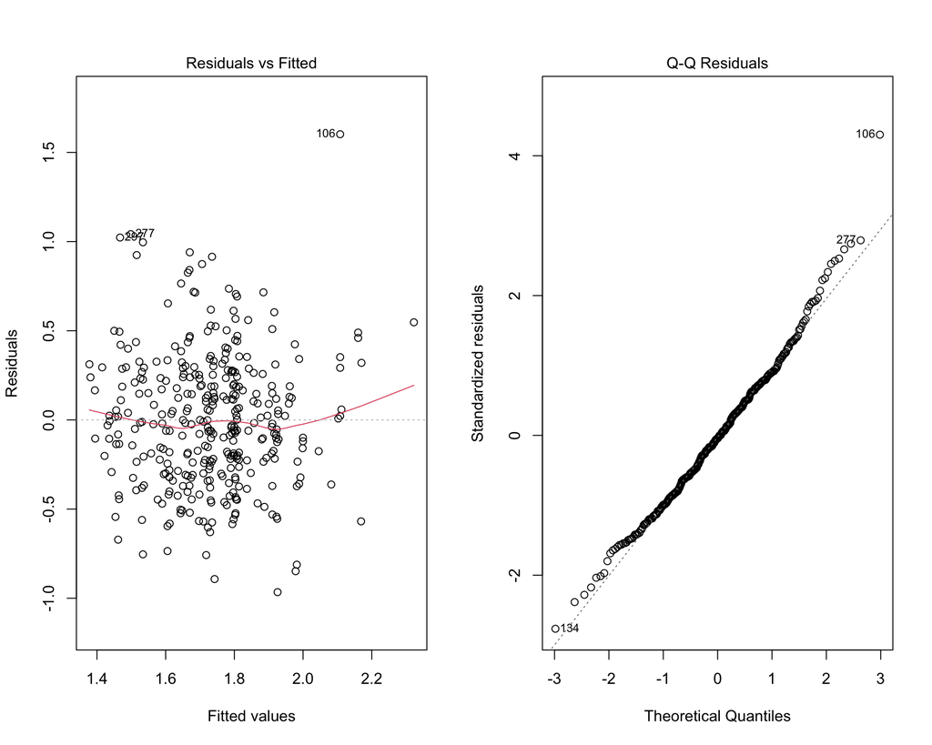

```r
# Diagnostics simples
par(mfrow = c(1, 2))
plot(mod_final_lm, which = 1)
plot(mod_final_lm, which = 2)
```

```r
par(mfrow = c(1, 1))
tbl_regression(mod_final_lm, conf.int = T)
```

| **Characteristic** | **Beta** | **95% CI** | **p-value** |
| --- | --- | --- | --- |
| age_cat |  |  |  |
| 18-29 | — | — |  |
| 30-39 | 0.06 | -0.08, 0.21 | 0.4 |
| 40-49 | 0.07 | -0.06, 0.20 | 0.3 |
| 50-59 | 0.18 | 0.04, 0.32 | 0.010 |
| ≥60 | -0.01 | -0.19, 0.17 | >0.9 |
| sexe |  |  |  |
| Homme | — | — |  |
| Femme | 0.15 | 0.05, 0.25 | 0.004 |
| tour_tail_cat |  |  |  |
| Normal | — | — |  |
| Risque modéré | 0.06 | -0.06, 0.17 | 0.3 |
| Risque très élevé | 0.13 | 0.02, 0.24 | 0.020 |
| IPAQ | 0.00 | 0.00, 0.00 | 0.2 |
| ATCD_HTA |  |  |  |
| Non | — | — |  |
| Oui | 0.19 | 0.08, 0.29 | <0.001 |
| ATCD_diab |  |  |  |
| Non | — | — |  |
| Oui | 0.25 | -0.02, 0.52 | 0.071 |

Abbreviation: CI = Confidence Interval

### 5.5.2 HDL-cholestérol

```r
# sélection AIC (hdl comme outcome)

formule2_lm <- hdl ~ age_cat + sexe + IMC + tour_tail_cat + alcool +
  IPAQ + socioeco_cat +
  duree_trait +
  tabac + REAPS + PSS +
  ATCD_HTA + ATCD_diab + ATCD_chol + ATCD_cardio +
  stade_VIH +
  ARV + chang_ARV

# Complete-cases sur toutes les variables de `mod1_lm` (necessaire pour `step()`)
data_lm <- stats::model.frame(formule2_lm, data = data_comp, na.action = stats::na.omit)

mod2_lm <- lm(
  formule2_lm,
  data = data_lm
)

summary(mod2_lm)
```

```
##
## Call:
## lm(formula = formule2_lm, data = data_lm)
##
## Residuals:
##      Min       1Q   Median       3Q      Max
## -0.73945 -0.22880 -0.01274  0.21149  0.97380
##
## Coefficients:
##                                  Estimate Std. Error t value Pr(>|t|)
## (Intercept)                     6.210e-01  1.686e-01   3.683  0.00027 ***
## age_cat30-39                    3.040e-02  6.814e-02   0.446  0.65577
## age_cat40-49                   -6.362e-03  6.409e-02  -0.099  0.92099
## age_cat50-59                    1.622e-01  7.196e-02   2.254  0.02485 *
## age_cat≥60                      4.149e-03  9.049e-02   0.046  0.96345
## sexeFemme                       6.694e-02  5.165e-02   1.296  0.19591
## IMC                             2.971e-04  7.175e-04   0.414  0.67907
## tour_tail_catRisque modéré      4.868e-02  5.511e-02   0.883  0.37770
## tour_tail_catRisque très élevé  1.521e-01  5.222e-02   2.912  0.00384 **
## alcoolOui                       4.717e-02  6.809e-02   0.693  0.48900
## IPAQ                           -1.955e-05  1.860e-05  -1.051  0.29400
## socioeco_catÉlevé               1.292e-01  6.767e-02   1.909  0.05718 .
## socioeco_catMoyen               4.248e-02  4.536e-02   0.937  0.34962
## duree_trait                     2.344e-02  1.379e-02   1.699  0.09021 .
## tabacNon                        6.013e-02  7.628e-02   0.788  0.43112
## REAPS                          -3.925e-03  3.194e-03  -1.229  0.22000
## PSS                            -8.557e-03  1.926e-02  -0.444  0.65707
## ATCD_HTAOui                     1.043e-01  5.465e-02   1.909  0.05720 .
## ATCD_diabOui                    2.832e-01  1.375e-01   2.060  0.04019 *
## ATCD_cholOui                    4.892e-02  1.514e-01   0.323  0.74685
## ATCD_cardioOui                  6.958e-02  1.066e-01   0.653  0.51425
## stade_VIHStade 2                1.322e-01  5.715e-02   2.314  0.02130 *
## stade_VIHStade 3                2.388e-02  5.126e-02   0.466  0.64162
## stade_VIHStade 4                1.102e-01  8.531e-02   1.292  0.19728
## ARVTDF-3TC-EFV                  1.229e-01  1.467e-01   0.838  0.40288
## ARVABC-3TC-DTG                  4.239e-01  1.611e-01   2.631  0.00891 **
## ARVAZT-3TC-LPV/r                3.074e-01  3.580e-01   0.859  0.39124
## ARVAutre à préciser             4.858e-02  1.775e-01   0.274  0.78454
## chang_ARVOui                    8.392e-03  4.203e-02   0.200  0.84187
## ---
## Signif. codes:  0 '***' 0.001 '**' 0.01 '*' 0.05 '.' 0.1 ' ' 1
##
## Residual standard error: 0.3448 on 323 degrees of freedom
## Multiple R-squared:  0.1782, Adjusted R-squared:  0.1069
## F-statistic: 2.501 on 28 and 323 DF,  p-value: 6.866e-05
```

```r
mod_final2_lm <- step(mod2_lm, direction = "backward", trace = 0)

summary(mod_final2_lm)
```

```
##
## Call:
## lm(formula = hdl ~ age_cat + sexe + tour_tail_cat + socioeco_cat +
##     duree_trait + ATCD_HTA + ATCD_diab + stade_VIH + ARV, data = data_lm)
##
## Residuals:
##      Min       1Q   Median       3Q      Max
## -0.82873 -0.22671 -0.01909  0.22403  1.00305
##
## Coefficients:
##                                  Estimate Std. Error t value Pr(>|t|)
## (Intercept)                     0.5631096  0.0919767   6.122  2.6e-09 ***
## age_cat30-39                    0.0375921  0.0663260   0.567  0.57125
## age_cat40-49                   -0.0003179  0.0616271  -0.005  0.99589
## age_cat50-59                    0.1624691  0.0680724   2.387  0.01756 *
## age_cat≥60                      0.0151406  0.0863181   0.175  0.86087
## sexeFemme                       0.0762238  0.0476840   1.599  0.11088
## tour_tail_catRisque modéré      0.0457936  0.0540476   0.847  0.39745
## tour_tail_catRisque très élevé  0.1493306  0.0506565   2.948  0.00343 **
## socioeco_catÉlevé               0.1351324  0.0666715   2.027  0.04348 *
## socioeco_catMoyen               0.0511080  0.0445238   1.148  0.25184
## duree_trait                     0.0229336  0.0135212   1.696  0.09080 .
## ATCD_HTAOui                     0.1113084  0.0507948   2.191  0.02912 *
## ATCD_diabOui                    0.3151865  0.1261371   2.499  0.01295 *
## stade_VIHStade 2                0.1269560  0.0566074   2.243  0.02557 *
## stade_VIHStade 3                0.0303721  0.0506611   0.600  0.54924
## stade_VIHStade 4                0.1199526  0.0833156   1.440  0.15088
## ARVTDF-3TC-EFV                  0.0921251  0.1439449   0.640  0.52261
## ARVABC-3TC-DTG                  0.4301896  0.1582625   2.718  0.00691 **
## ARVAZT-3TC-LPV/r                0.3148364  0.3482242   0.904  0.36659
## ARVAutre à préciser             0.0279735  0.1741951   0.161  0.87252
## ---
## Signif. codes:  0 '***' 0.001 '**' 0.01 '*' 0.05 '.' 0.1 ' ' 1
##
## Residual standard error: 0.3426 on 332 degrees of freedom
## Multiple R-squared:  0.166,  Adjusted R-squared:  0.1183
## F-statistic: 3.479 on 19 and 332 DF,  p-value: 2.009e-06
```

```r
# AIC des deux modèles
AIC(mod2_lm, mod_final2_lm)
```

```
##               df      AIC
## mod2_lm       30 279.1278
## mod_final2_lm 21 266.2950
```

```r
# IC95% des coefficients
confint(mod_final2_lm)
```

```
##                                       2.5 %     97.5 %
## (Intercept)                     0.382179056 0.74404016
## age_cat30-39                   -0.092880004 0.16806425
## age_cat40-49                   -0.121546629 0.12091084
## age_cat50-59                    0.028561561 0.29637670
## age_cat≥60                     -0.154658720 0.18494001
## sexeFemme                      -0.017577186 0.17002471
## tour_tail_catRisque modéré     -0.060525279 0.15211244
## tour_tail_catRisque très élevé  0.049682505 0.24897867
## socioeco_catÉlevé               0.003980454 0.26628433
## socioeco_catMoyen              -0.036476371 0.13869246
## duree_trait                    -0.003664420 0.04953162
## ATCD_HTAOui                     0.011388247 0.21122856
## ATCD_diabOui                    0.067057795 0.56331518
## stade_VIHStade 2                0.015601643 0.23831030
## stade_VIHStade 3               -0.069285088 0.13002921
## stade_VIHStade 4               -0.043940399 0.28384560
## ARVTDF-3TC-EFV                 -0.191034033 0.37528418
## ARVABC-3TC-DTG                  0.118865941 0.74151329
## ARVAZT-3TC-LPV/r               -0.370167690 0.99984050
## ARVAutre à préciser            -0.314691782 0.37063879
```

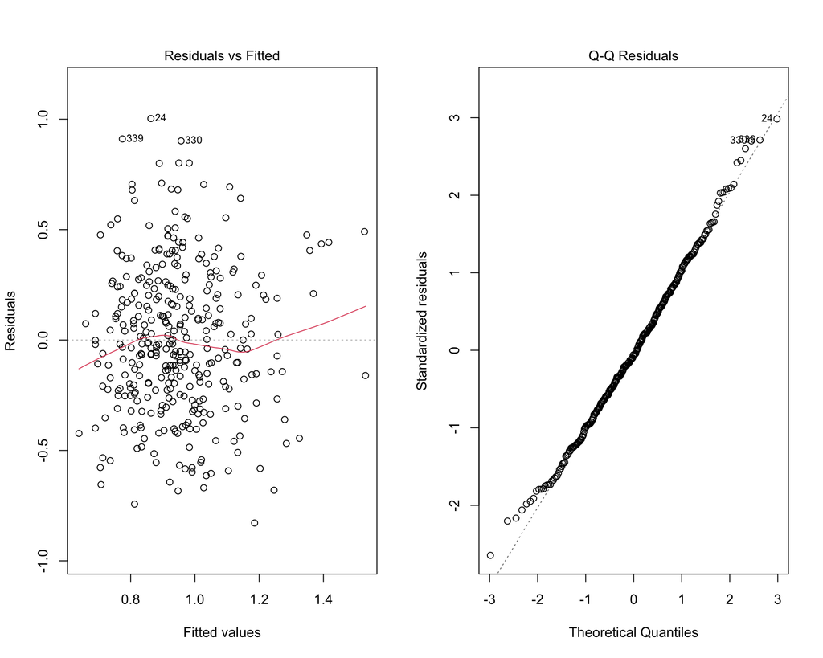

```r
# Diagnostics simples
par(mfrow = c(1, 2))
plot(mod_final2_lm, which = 1)
plot(mod_final2_lm, which = 2)
```

```r
par(mfrow = c(1, 1))
tbl_regression(mod_final2_lm, conf.int = T)
```

| **Characteristic** | **Beta** | **95% CI** | **p-value** |
| --- | --- | --- | --- |
| age_cat |  |  |  |
| 18-29 | — | — |  |
| 30-39 | 0.04 | -0.09, 0.17 | 0.6 |
| 40-49 | 0.00 | -0.12, 0.12 | >0.9 |
| 50-59 | 0.16 | 0.03, 0.30 | 0.018 |
| ≥60 | 0.02 | -0.15, 0.18 | 0.9 |
| sexe |  |  |  |
| Homme | — | — |  |
| Femme | 0.08 | -0.02, 0.17 | 0.11 |
| tour_tail_cat |  |  |  |
| Normal | — | — |  |
| Risque modéré | 0.05 | -0.06, 0.15 | 0.4 |
| Risque très élevé | 0.15 | 0.05, 0.25 | 0.003 |
| socioeco_cat |  |  |  |
| Bas | — | — |  |
| Élevé | 0.14 | 0.00, 0.27 | 0.043 |
| Moyen | 0.05 | -0.04, 0.14 | 0.3 |
| duree_trait | 0.02 | 0.00, 0.05 | 0.091 |
| ATCD_HTA |  |  |  |
| Non | — | — |  |
| Oui | 0.11 | 0.01, 0.21 | 0.029 |
| ATCD_diab |  |  |  |
| Non | — | — |  |
| Oui | 0.32 | 0.07, 0.56 | 0.013 |
| stade_VIH |  |  |  |
| Stade 1 | — | — |  |
| Stade 2 | 0.13 | 0.02, 0.24 | 0.026 |
| Stade 3 | 0.03 | -0.07, 0.13 | 0.5 |
| Stade 4 | 0.12 | -0.04, 0.28 | 0.2 |
| ARV |  |  |  |
| TDF-3TC-DTG | — | — |  |
| TDF-3TC-EFV | 0.09 | -0.19, 0.38 | 0.5 |
| ABC-3TC-DTG | 0.43 | 0.12, 0.74 | 0.007 |
| AZT-3TC-LPV/r | 0.31 | -0.37, 1.0 | 0.4 |
| Autre à préciser | 0.03 | -0.31, 0.37 | 0.9 |

Abbreviation: CI = Confidence Interval

### 5.5.3 Triglycérides

```r
# sélection AIC (triglycerides comme outcome)

formule3_lm <- triglycerides ~ age_cat + sexe + IMC_cat + tour_tail_cat + alcool +
  IPAQ_cat + socioeco_cat +
  duree_trait +
  tabac + REAPS + PSS +
  ATCD_HTA + ATCD_diab + ATCD_chol + ATCD_cardio +
  stade_VIH +
  ARV + chang_ARV

# Complete-cases sur toutes les variables de `mod1_lm` (necessaire pour `step()`)
data3_lm <- stats::model.frame(formule3_lm, data = data_comp, na.action = stats::na.omit)

mod3_lm <- lm(
  formule3_lm,
  data = data3_lm
)

summary(mod3_lm)
```

```
##
## Call:
## lm(formula = formule3_lm, data = data3_lm)
##
## Residuals:
##     Min      1Q  Median      3Q     Max
## -0.8396 -0.2304 -0.0597  0.1376  3.0329
##
## Coefficients:
##                                 Estimate Std. Error t value Pr(>|t|)
## (Intercept)                     0.913604   0.216856   4.213 3.28e-05 ***
## age_cat30-39                   -0.080547   0.080332  -1.003  0.31678
## age_cat40-49                   -0.049273   0.076018  -0.648  0.51734
## age_cat50-59                    0.026234   0.084830   0.309  0.75733
## age_cat≥60                     -0.067515   0.107483  -0.628  0.53036
## sexeFemme                      -0.102469   0.062073  -1.651  0.09976 .
## IMC_catNormal                   0.143135   0.113771   1.258  0.20927
## IMC_catObésité                  0.196563   0.137670   1.428  0.15433
## IMC_catSurpoids                 0.066396   0.132024   0.503  0.61537
## tour_tail_catRisque modéré      0.044797   0.070433   0.636  0.52522
## tour_tail_catRisque très élevé  0.177714   0.086359   2.058  0.04041 *
## alcoolOui                      -0.108961   0.082290  -1.324  0.18641
## IPAQ_catModérée                -0.022896   0.050634  -0.452  0.65144
## IPAQ_catÉlevée                 -0.058063   0.110635  -0.525  0.60007
## socioeco_catÉlevé               0.057123   0.080341   0.711  0.47759
## socioeco_catMoyen              -0.007729   0.053511  -0.144  0.88524
## duree_trait                    -0.003763   0.016331  -0.230  0.81789
## tabacNon                       -0.081132   0.089824  -0.903  0.36708
## REAPS                          -0.002614   0.003786  -0.691  0.49034
## PSS                            -0.010906   0.022725  -0.480  0.63162
## ATCD_HTAOui                    -0.030670   0.065587  -0.468  0.64037
## ATCD_diabOui                    0.085049   0.163018   0.522  0.60223
## ATCD_cholOui                    0.185269   0.177063   1.046  0.29619
## ATCD_cardioOui                  0.029496   0.126852   0.233  0.81628
## stade_VIHStade 2                0.033336   0.067760   0.492  0.62308
## stade_VIHStade 3                0.039205   0.060468   0.648  0.51722
## stade_VIHStade 4                0.042694   0.099808   0.428  0.66911
## ARVTDF-3TC-EFV                  0.476080   0.175653   2.710  0.00708 **
## ARVABC-3TC-DTG                  0.553480   0.190693   2.902  0.00396 **
## ARVAZT-3TC-LPV/r                0.150180   0.422843   0.355  0.72270
## ARVAutre à préciser             0.005550   0.210135   0.026  0.97894
## chang_ARVOui                    0.070934   0.049586   1.431  0.15354
## ---
## Signif. codes:  0 '***' 0.001 '**' 0.01 '*' 0.05 '.' 0.1 ' ' 1
##
## Residual standard error: 0.4058 on 320 degrees of freedom
## Multiple R-squared:  0.1217, Adjusted R-squared:  0.03657
## F-statistic:  1.43 on 31 and 320 DF,  p-value: 0.06927
```

```r
mod_final3_lm <- step(mod3_lm, direction = "backward", trace = 0)

summary(mod_final3_lm)
```

```
##
## Call:
## lm(formula = triglycerides ~ sexe + IMC_cat + tour_tail_cat +
##     ARV + chang_ARV, data = data3_lm)
##
## Residuals:
##      Min       1Q   Median       3Q      Max
## -0.82412 -0.22091 -0.05675  0.14990  3.09555
##
## Coefficients:
##                                 Estimate Std. Error t value Pr(>|t|)
## (Intercept)                     0.692041   0.108256   6.393 5.38e-10 ***
## sexeFemme                      -0.131267   0.053509  -2.453  0.01466 *
## IMC_catNormal                   0.101074   0.107491   0.940  0.34773
## IMC_catObésité                  0.144147   0.129374   1.114  0.26599
## IMC_catSurpoids                 0.007047   0.124347   0.057  0.95484
## tour_tail_catRisque modéré      0.044377   0.067241   0.660  0.50972
## tour_tail_catRisque très élevé  0.184969   0.081535   2.269  0.02392 *
## ARVTDF-3TC-EFV                  0.428579   0.167300   2.562  0.01085 *
## ARVABC-3TC-DTG                  0.533948   0.182281   2.929  0.00363 **
## ARVAZT-3TC-LPV/r                0.270767   0.403386   0.671  0.50253
## ARVAutre à préciser            -0.024148   0.202592  -0.119  0.90519
## chang_ARVOui                    0.067384   0.045669   1.475  0.14100
## ---
## Signif. codes:  0 '***' 0.001 '**' 0.01 '*' 0.05 '.' 0.1 ' ' 1
##
## Residual standard error: 0.3993 on 340 degrees of freedom
## Multiple R-squared:  0.09641,    Adjusted R-squared:  0.06718
## F-statistic: 3.298 on 11 and 340 DF,  p-value: 0.0002554
```

```r
# AIC des deux modèles
AIC(mod3_lm, mod_final3_lm)
```

```
##               df      AIC
## mod3_lm       33 396.4949
## mod_final3_lm 13 366.4721
```

```r
# IC95% des coefficients
confint(mod_final3_lm)
```

```
##                                      2.5 %      97.5 %
## (Intercept)                     0.47910471  0.90497771
## sexeFemme                      -0.23651731 -0.02601582
## IMC_catNormal                  -0.11035694  0.31250572
## IMC_catObésité                 -0.11032731  0.39862053
## IMC_catSurpoids                -0.23753932  0.25163385
## tour_tail_catRisque modéré     -0.08788335  0.17663708
## tour_tail_catRisque très élevé  0.02459325  0.34534471
## ARVTDF-3TC-EFV                  0.09950652  0.75765148
## ARVABC-3TC-DTG                  0.17540764  0.89248892
## ARVAZT-3TC-LPV/r               -0.52267904  1.06421245
## ARVAutre à préciser            -0.42263979  0.37434445
## chang_ARVOui                   -0.02244475  0.15721327
```

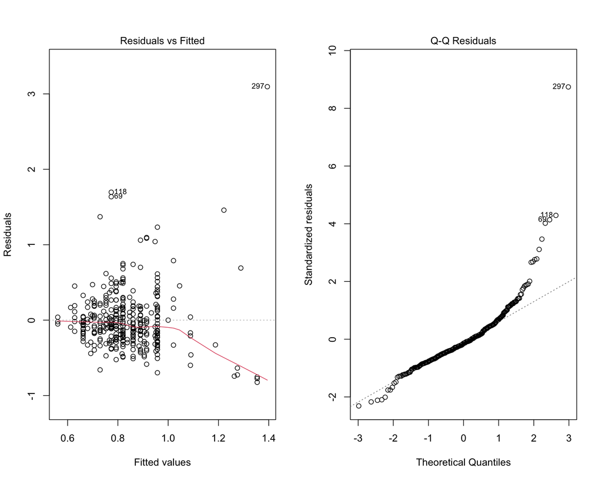

```r
# Diagnostics simples
par(mfrow = c(1, 2))
plot(mod_final3_lm, which = 1)
plot(mod_final3_lm, which = 2)
```

```r
par(mfrow = c(1, 1))
tbl_regression(mod_final3_lm, conf.int = T)
```

| **Characteristic** | **Beta** | **95% CI** | **p-value** |
| --- | --- | --- | --- |
| sexe |  |  |  |
| Homme | — | — |  |
| Femme | -0.13 | -0.24, -0.03 | 0.015 |
| IMC_cat |  |  |  |
| Insuffisance pondérale | — | — |  |
| Normal | 0.10 | -0.11, 0.31 | 0.3 |
| Obésité | 0.14 | -0.11, 0.40 | 0.3 |
| Surpoids | 0.01 | -0.24, 0.25 | >0.9 |
| tour_tail_cat |  |  |  |
| Normal | — | — |  |
| Risque modéré | 0.04 | -0.09, 0.18 | 0.5 |
| Risque très élevé | 0.18 | 0.02, 0.35 | 0.024 |
| ARV |  |  |  |
| TDF-3TC-DTG | — | — |  |
| TDF-3TC-EFV | 0.43 | 0.10, 0.76 | 0.011 |
| ABC-3TC-DTG | 0.53 | 0.18, 0.89 | 0.004 |
| AZT-3TC-LPV/r | 0.27 | -0.52, 1.1 | 0.5 |
| Autre à préciser | -0.02 | -0.42, 0.37 | >0.9 |
| chang_ARV |  |  |  |
| Non | — | — |  |
| Oui | 0.07 | -0.02, 0.16 | 0.14 |

Abbreviation: CI = Confidence Interval

## 5.6 Modèles d’équations structurelles — médiation (SEM)

```r
library(lavaan)

model <- '
  # médiation
  REAPS ~ a*tour_tail
  chol_total ~ c*tour_tail + b*REAPS
'

fit <- sem(model, data = data_comp, se = "bootstrap", bootstrap = 1000)
summary(fit)
```

```
## lavaan 0.6-21 ended normally after 1 iteration
##
##   Estimator                                         ML
##   Optimization method                           NLMINB
##   Number of model parameters                         5
##
##   Number of observations                           354
##
## Model Test User Model:
##
##   Test statistic                                 0.000
##   Degrees of freedom                                 0
##
## Parameter Estimates:
##
##   Standard errors                            Bootstrap
##   Number of requested bootstrap draws             1000
##   Number of successful bootstrap draws            1000
##
## Regressions:
##                    Estimate  Std.Err  z-value  P(>|z|)
##   REAPS ~
##     tour_tail  (a)    0.090    0.025    3.682    0.000
##   chol_total ~
##     tour_tail  (c)    0.006    0.002    3.893    0.000
##     REAPS      (b)    0.002    0.004    0.496    0.620
##
## Variances:
##                    Estimate  Std.Err  z-value  P(>|z|)
##    .REAPS            36.185    2.209   16.379    0.000
##    .chol_total        0.156    0.014   11.128    0.000
```

**Commentaires**

Régression REAPS ~ tour_tail (a)

Estimate = 0.090, p < 0.001 Le tour de taille est positivement et significativement associé au score REAPS. Plus le tour de taille est élevé, plus le score REAPS augmente.

Régression chol_total ~ tour_tail (c)

Estimate = 0.006, p < 0.001 Le tour de taille est aussi directement et significativement associé au cholestérol total. Cela confirme un effet direct.

Régression chol_total ~ REAPS (b)

- Le tour de taille influence directement le cholestérol total (effet significatif).
- Le tour de taille influence aussi REAPS, mais REAPS n’a pas d’effet significatif sur le cholestérol total.
- Par conséquent, il n’y a pas de médiation significative de REAPS dans la relation entre tour de taille et cholestérol total.
- Le modèle montre que l’effet observé est essentiellement direct (tour de taille → cholestérol total), sans passer par REAPS.

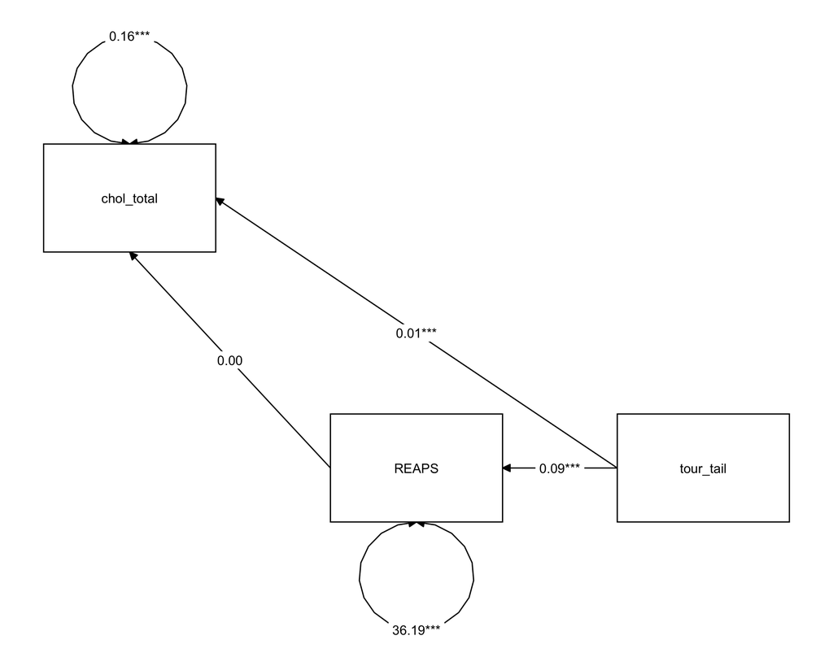

```r
library(tidySEM)

graph_sem(
  model = fit,
  edge_labels = "estimate"
)
```

```r
model1 <- '
  # médiation
  REAPS ~ a*tour_tail
  triglycerides ~ c*tour_tail + b*REAPS
'

fit1 <- sem(model1, data = data_comp, se = "bootstrap", bootstrap = 1000)
summary(fit1)
```

```
## lavaan 0.6-21 ended normally after 1 iteration
##
##   Estimator                                         ML
##   Optimization method                           NLMINB
##   Number of model parameters                         5
##
##   Number of observations                           354
##
## Model Test User Model:
##
##   Test statistic                                 0.000
##   Degrees of freedom                                 0
##
## Parameter Estimates:
##
##   Standard errors                            Bootstrap
##   Number of requested bootstrap draws             1000
##   Number of successful bootstrap draws            1000
##
## Regressions:
##                    Estimate  Std.Err  z-value  P(>|z|)
##   REAPS ~
##     tour_tail  (a)    0.090    0.023    3.885    0.000
##   triglycerides ~
##     tour_tail  (c)    0.007    0.002    4.210    0.000
##     REAPS      (b)   -0.004    0.003   -1.025    0.305
##
## Variances:
##                    Estimate  Std.Err  z-value  P(>|z|)
##    .REAPS            36.185    2.339   15.470    0.000
##    .triglycerides     0.163    0.043    3.751    0.000
```

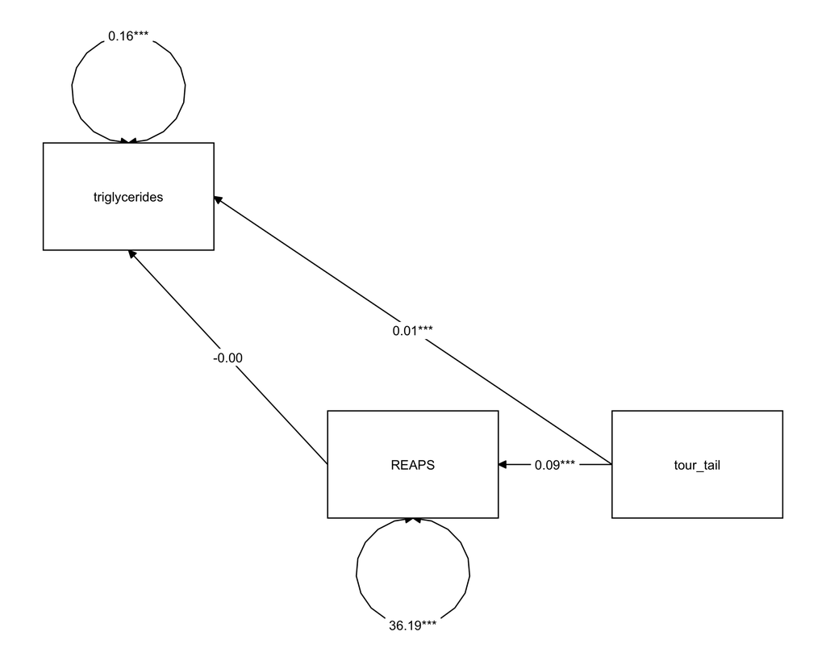

```r
graph_sem(
  model = fit1,
  edge_labels = "estimate"
)
```

```r
model2 <- '
  # médiation
  REAPS ~ a*tour_tail
  hdl ~ c*tour_tail + b*REAPS
'

fit2 <- sem(model2, data = data_comp, se = "bootstrap", bootstrap = 1000)
summary(fit2)
```

```
## lavaan 0.6-21 ended normally after 1 iteration
##
##   Estimator                                         ML
##   Optimization method                           NLMINB
##   Number of model parameters                         5
##
##   Number of observations                           354
##
## Model Test User Model:
##
##   Test statistic                                 0.000
##   Degrees of freedom                                 0
##
## Parameter Estimates:
##
##   Standard errors                            Bootstrap
##   Number of requested bootstrap draws             1000
##   Number of successful bootstrap draws            1000
##
## Regressions:
##                    Estimate  Std.Err  z-value  P(>|z|)
##   REAPS ~
##     tour_tail  (a)    0.090    0.024    3.819    0.000
##   hdl ~
##     tour_tail  (c)    0.006    0.001    4.185    0.000
##     REAPS      (b)   -0.002    0.003   -0.718    0.473
##
## Variances:
##                    Estimate  Std.Err  z-value  P(>|z|)
##    .REAPS            36.185    2.207   16.398    0.000
##    .hdl               0.126    0.009   13.763    0.000
```

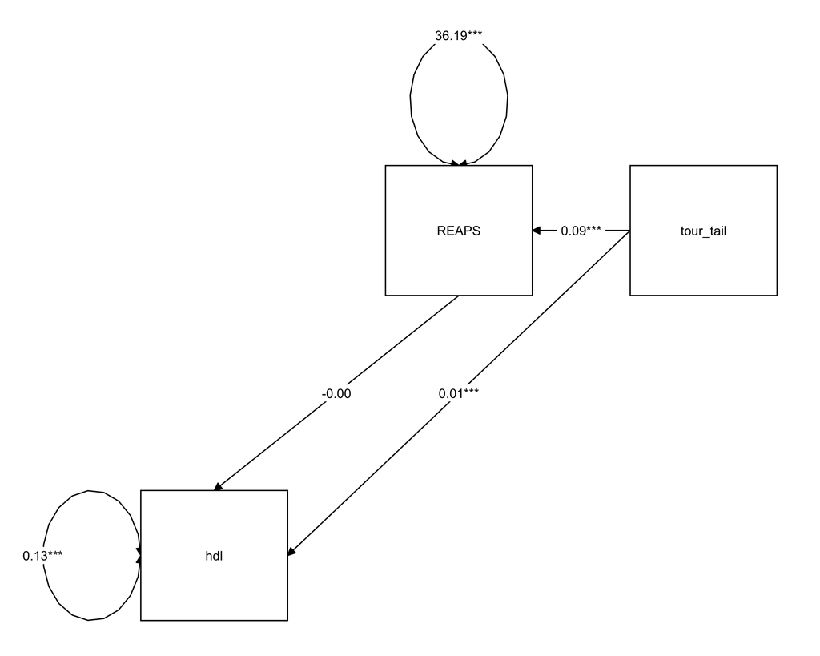

```r
graph_sem(
  model = fit2,
  edge_labels = "estimate"
)
```

```r
model3 <- '
  # médiation
  REAPS ~ a*AUDITC
  hdl ~ c*AUDITC + b*REAPS
'

fit3 <- sem(model3, data = data_comp, se = "bootstrap", bootstrap = 1000)
summary(fit3)
```

```
## lavaan 0.6-21 ended normally after 1 iteration
##
##   Estimator                                         ML
##   Optimization method                           NLMINB
##   Number of model parameters                         5
##
##   Number of observations                           354
##
## Model Test User Model:
##
##   Test statistic                                 0.000
##   Degrees of freedom                                 0
##
## Parameter Estimates:
##
##   Standard errors                            Bootstrap
##   Number of requested bootstrap draws             1000
##   Number of successful bootstrap draws             999
##
## Regressions:
##                    Estimate  Std.Err  z-value  P(>|z|)
##   REAPS ~
##     AUDITC     (a)   -0.296    0.192   -1.541    0.123
##   hdl ~
##     AUDITC     (c)   -0.022    0.010   -2.193    0.028
##     REAPS      (b)   -0.000    0.003   -0.097    0.922
##
## Variances:
##                    Estimate  Std.Err  z-value  P(>|z|)
##    .REAPS            37.382    2.225   16.804    0.000
##    .hdl               0.131    0.010   13.561    0.000
```

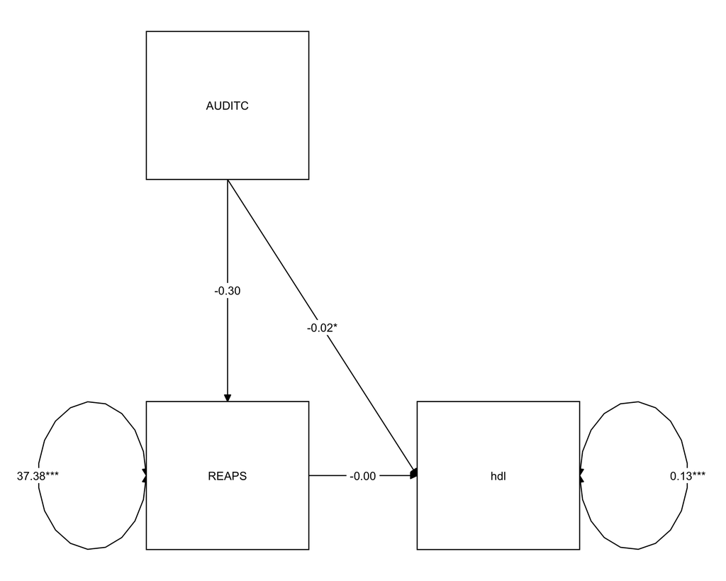

```r
graph_sem(
  model = fit3,
  edge_labels = "estimate"
)
```